# Nigeria Crop Consumption

The denominator remains household size for EVERY household.

This avoids the serious bias that would occur if we only analysed households that consumed the product.

```r
# 15. FUNCTION FOR ONE PRODUCT
# ------------------------------------------------------------

make_product_design <- function(product_name, hh_analysis, food_hh) {
  product_data <- hh_analysis |>
    select(
      hhid,
      zone,
      state,
      lga,
      sector,
      ea,
      cluster,
      strata,
      wt_cross_wave5,
      hh_size
    ) |>
    left_join(
      food_hh |>
        filter(
          product == product_name
        ) |>
        select(
          hhid,
          kg_week
        ),
      by = "hhid"
    ) |>
    mutate(
      kg_week = replace_na(
        kg_week,
        0
      )
    )

  svydesign(
    ids = ~cluster,
    strata = ~strata,
    weights = ~wt_cross_wave5,
    data = product_data,
    nest = TRUE
  )
}

# ------------------------------------------------------------
# 16. FUNCTION TO EXTRACT RATIO ESTIMATE
#
# Ratio:
#
# weighted total kg/week
# ---------------------
# weighted total persons
#
# This gives kg/person/week.
# ------------------------------------------------------------

extract_ratio <- function(
  design,
  by_variable,
  denominator = ~hh_size
) {
  result <- svyby(
    formula = ~kg_week,
    by = by_variable,
    design = design,
    FUN = svyratio,
    denominator = denominator,
    na.rm = TRUE,
    keep.names = FALSE,
    vartype = c("se", "cv")
  )

  names(result) <- c(
    all.vars(by_variable),
    "estimate_kg_person_week",
    "se",
    "cv"
  )

  result |>
    mutate(
      ci_low = pmax(
        0,
        estimate_kg_person_week - 1.96 * se
      ),
      ci_high = estimate_kg_person_week + 1.96 * se,
      # Annualized equivalent is included only as a convenient
      # comparison scale. It is NOT an observed annual total.
      estimate_kg_person_year_equivalent = estimate_kg_person_week * 365 / 7
    )
}
```

```r
# ------------------------------------------------------------
# 17. PRODUCTS TO ANALYSE
# ------------------------------------------------------------

products_pp <- sort(
  unique(
    df_food_pp_consumed_standard_hh$product
  )
)

cat("\n\nPost Planting Survey Number of products:",length(products_pp),"\n")
```

Post Planting Survey Number of products: 111

```r
products_pp
```

[1] “Agricultural eggs” “Animal fat”  
[3] “Apples” “Avocado pear”  
[5] “Baby milk powder” “Bananas”  
[7] “Beef” “Beer”  
[9] “Biscuits” “Bottled water”  
[11] “Bread” “Brown beans”  
[13] “Buns/Pofpof/Donuts” “Butter/Margarine”  
[15] “Cake” “Canned fish/seafood”  
[17] “Cashew nut” “Cassava flour”  
[19] “Cassava roots” “Cheese/wara”  
[21] “Chicken” “Chocolate drinks”  
[23] “Coconut” “Cocoyam”  
[25] “Coffee” “Dry pepper”  
[27] “Duck” “Fish - dried”  
[29] “Fish - fresh” “Fish - frozen”  
[31] “Fish - smoked” “Fresh milk”  
[33] “Fresh pepper” “Fruit juice”  
[35] “Garden eggs/Eggplant” “Gari - white”  
[37] “Gari - yellow” “Gin”  
[39] “Goat” “Ground pepper”  
[41] “Groundnut oil” “Groundnuts - shelled”  
[43] “Groundnuts - unshelled” “Guava”  
[45] “Guinea corn / sorghum” “Honey”  
[47] “Kola nut” “Leaves”  
[49] “Local eggs” “Maize - shelled/off cob”  
[51] “Maize - unshelled/on cob” “Maize flour”  
[53] “Malt drinks” “Mangoes”  
[55] “Meat pie/Sausage roll” “Melon - ground”  
[57] “Melon - shelled” “Melon - unshelled”  
[59] “Milk - tinned” “Milk powder”  
[61] “Millet” “Mutton”  
[63] “Ogbono - ground” “Ogbono - unground”  
[65] “Okra - dried” “Okra - fresh”  
[67] “Onions” “Orange/Tangerine”  
[69] “Other alcoholic beverages” “Other domestic poultry”  
[71] “Other eggs” “Other fish/seafood”  
[73] “Other fruits” “Other grains/flour”  
[75] “Other meat” “Other milk products”  
[77] “Other non-alcoholic drinks” “Other nuts/seeds/pulses”  
[79] “Other oil/fat” “Other roots/tubers”  
[81] “Other spices” “Other sweets”  
[83] “Other vegetables” “Palm oil”  
[85] “Palm wine” “Pawpaw”  
[87] “Pineapples” “Pito”  
[89] “Plantains” “Pork”  
[91] “Potatoes” “Rice - imported”  
[93] “Rice - local” “Sachet water”  
[95] “Salt” “Seafood”  
[97] “Shea butter” “Snails”  
[99] “Soft drinks” “Soya beans”  
[101] “Sugar” “Sweet potatoes”  
[103] “Tea” “Tomato puree - canned”  
[105] “Tomatoes” “Watermelon”  
[107] “Wheat flour” “White beans”  
[109] “Wild game/Bush meat” “Yam flour”  
[111] “Yam roots”

```r
products_ph <- sort(
  unique(
    df_food_ph_consumed_standard_hh$product
  )
)

cat("\n\nPost Harvest Survey Number of products:",length(products_ph),"\n")
```

Post Harvest Survey Number of products: 107

```r
products_ph
```

[1] “Agricultural eggs” “Animal fat”  
[3] “Apples” “Avocado pear”  
[5] “Baby milk powder” “Bananas”  
[7] “Beef” “Beer”  
[9] “Biscuits” “Bottled water”  
[11] “Bread” “Brown beans”  
[13] “Buns/Pofpof/Donuts” “Butter/Margarine”  
[15] “Cake” “Canned fish/seafood”  
[17] “Cashew nut” “Cassava flour”  
[19] “Cassava roots” “Cheese/wara”  
[21] “Chicken” “Chocolate drinks”  
[23] “Coconut” “Cocoyam”  
[25] “Coffee” “Dry pepper”  
[27] “Duck” “Fish - dried”  
[29] “Fish - fresh” “Fish - frozen”  
[31] “Fish - smoked” “Fresh milk”  
[33] “Fresh pepper” “Fruit juice”  
[35] “Garden eggs/Eggplant” “Gari - white”  
[37] “Gari - yellow” “Gin”  
[39] “Goat” “Ground pepper”  
[41] “Groundnut oil” “Groundnuts - shelled”  
[43] “Groundnuts - unshelled” “Guava”  
[45] “Guinea corn / sorghum” “Honey”  
[47] “Kola nut” “Leaves”  
[49] “Local eggs” “Maize - shelled/off cob”  
[51] “Maize - unshelled/on cob” “Maize flour”  
[53] “Malt drinks” “Mangoes”  
[55] “Meat pie/Sausage roll” “Melon - ground”  
[57] “Melon - shelled” “Melon - unshelled”  
[59] “Milk - tinned” “Milk powder”  
[61] “Millet” “Mutton”  
[63] “Ogbono - ground” “Ogbono - unground”  
[65] “Okra - dried” “Okra - fresh”  
[67] “Onions” “Orange/Tangerine”  
[69] “Other alcoholic beverages” “Other domestic poultry”  
[71] “Other eggs” “Other fish/seafood”  
[73] “Other fruits” “Other grains/flour”  
[75] “Other meat” “Other non-alcoholic drinks” [77] “Other nuts/seeds/pulses” “Other oil/fat”  
[79] “Other spices” “Other vegetables”  
[81] “Palm oil” “Palm wine”  
[83] “Pawpaw” “Pineapples”  
[85] “Pito” “Plantains”  
[87] “Pork” “Potatoes”  
[89] “Rice - imported” “Rice - local”  
[91] “Sachet water” “Salt”  
[93] “Seafood” “Snails”  
[95] “Soft drinks” “Soya beans”  
[97] “Sugar” “Sweet potatoes”  
[99] “Tea” “Tomato puree - canned”  
[101] “Tomatoes” “Watermelon”  
[103] “Wheat flour” “White beans”  
[105] “Wild game/Bush meat” “Yam flour”  
[107] “Yam roots”

```r
# 18. STATE-LEVEL RESULTS
# ------------------------------------------------------------

# ------------------------------------------------------------
# -------------POST PLANTING------------------
# ------------------------------------------------------------

state_results_list_pp <- vector(
  "list",
  length(products_pp)
)

for (i in seq_along(products_pp)) {
  p_pp <- products_pp[i]

  message(
    "State estimates: ",
    p_pp,
    " (",
    i,
    "/",
    length(products_pp),
    ")"
  )

  d_pp <- make_product_design(p_pp, df_hh_analysis_pp, df_food_pp_consumed_standard_hh)

  result_pp <- extract_ratio(
    d_pp,
    ~state
  )

  result_pp <- extract_ratio(d_pp, ~state) |>
    mutate(survey_period = "Post-Planting", product = p_pp, .before = 1)

  state_results_list_pp[[i]] <- result_pp
}

state_results_pp <- bind_rows(
  state_results_list_pp
)

# ------------------------------------------------------------
# 19. ADD 95% CONFIDENCE INTERVALS
# ------------------------------------------------------------

state_results_pp <- state_results_pp |>
  mutate(
    ci_low = pmax(
      0,
      estimate_kg_person_week -
        1.96 * se
    ),

    ci_high = estimate_kg_person_week +
      1.96 * se
  )

# ------------------------------------------------------------
# 20. ADD STATE SAMPLE INFORMATION
# ------------------------------------------------------------

state_results_pp <- state_results_pp |>
  left_join(
    state_sample_analysis_pp,
    by = "state"
  ) |>
  select(
    state,
    zone,
    survey_period,
    product,
    estimate_kg_person_week,
    se,
    ci_low,
    ci_high,
    cv,
    n_households,
    n_psu,
    weighted_population,
    median_household_size,
    mean_household_size,
    estimate_kg_person_year_equivalent
  ) |>
  arrange(
    state,
    product
  )

# -----------------------------------------------------------
# 21. PRECISION FLAG
#
# These are analytical flags, not NBS thresholds.
# ------------------------------------------------------------

state_results_pp <- state_results_pp |>
  mutate(
    precision_flag = case_when(
      is.na(cv) ~        "No estimate",
        cv < .10 ~        "CV < 10%",
        cv < .20 ~        "CV 10–20%",
        cv < .30 ~        "CV 20–30% — caution",
        TRUE ~        "CV > 30% — low precision"
    )
  )

# ------------------------------------------------------------
# -------------POST HARVEST------------------
# ------------------------------------------------------------

state_results_list_ph <- vector(
  "list",
  length(products_ph)
)

for (i in seq_along(products_ph)) {
  p_ph <- products_ph[i]

  message(
    "State estimates: ",
    p_ph,
    " (",
    i,
    "/",
    length(products_ph),
    ")"
  )

  d_ph <- make_product_design(p_ph, df_hh_analysis_ph, df_food_ph_consumed_standard_hh)

  result_ph <- extract_ratio(
    d_ph,
    ~state
  )

  result_ph <- extract_ratio(d_ph, ~state) |>
    mutate(survey_period = "Post-Harvest", product = p_ph, .before = 1)

  state_results_list_ph[[i]] <- result_ph
}

state_results_ph <- bind_rows(
  state_results_list_ph
)

# ------------------------------------------------------------
# 19. ADD 95% CONFIDENCE INTERVALS
# ------------------------------------------------------------

state_results_ph <- state_results_ph |>
  mutate(
    ci_low = pmax(
      0,
      estimate_kg_person_week -
        1.96 * se
    ),

    ci_high = estimate_kg_person_week +
      1.96 * se
  )

# ------------------------------------------------------------
# 20. ADD STATE SAMPLE INFORMATION
# ------------------------------------------------------------

state_results_ph <- state_results_ph |>
  left_join(
    state_sample_analysis_ph,
    by = "state"
  ) |>
  select(
    state,
    zone,
    survey_period,
    product,
    estimate_kg_person_week,
    se,
    ci_low,
    ci_high,
    cv,
    n_households,
    n_psu,
    weighted_population,
    median_household_size,
    mean_household_size,
    estimate_kg_person_year_equivalent
  ) |>
  arrange(
    state,
    product
  )

# ------------------------------------------------------------
# 21. PRECISION FLAG
#
# These are analytical flags, not NBS thresholds.
# ------------------------------------------------------------

state_results_ph <- state_results_ph |>
  mutate(
    precision_flag = case_when(
      is.na(cv) ~        "No estimate",
        cv < .10 ~        "CV < 10%",
        cv < .20 ~        "CV 10–20%",
        cv < .30 ~        "CV 20–30% — caution",
        TRUE ~        "CV > 30% — low precision"
    )
  )
```

```r
# ------------------------------------------------------------
# 22. ZONE-LEVEL RESULTS
# ------------------------------------------------------------

# ------------------------------------------------------------
# -------------POST PLANTING------------------
# ------------------------------------------------------------

zone_results_list_pp <- vector(
  "list",
  length(products_pp)
)

for (i in seq_along(products_pp)) {
  p_pp <- products_pp[i]

  message(
    "Zone estimates: ",
    p_pp,
    " (",
    i,
    "/",
    length(products_pp),
    ")"
  )

  d_pp <- make_product_design(p_pp, df_hh_analysis_pp, df_food_pp_consumed_standard_hh)

  result_pp <- extract_ratio(d_pp, ~zone) |>
    mutate(survey_period = "Post-Planting", product = p_pp, .before = 1)

  zone_results_list_pp[[i]] <- result_pp
}

zone_results_pp <- bind_rows(
  zone_results_list_pp
) |>
  mutate(
    ci_low = pmax(
      0,
      estimate_kg_person_week -
        1.96 * se
    ),
    ci_high = estimate_kg_person_week +
      1.96 * se
  ) |>
  arrange(
    zone,
    product
  )

# ------------------------------------------------------------
# -------------POST HARVEST------------------
# ------------------------------------------------------------

zone_results_list_ph <- vector(
  "list",
  length(products_ph)
)

for (i in seq_along(products_ph)) {
  p_ph <- products_ph[i]

  message(
    "Zone estimates: ",
    p_ph,
    " (",
    i,
    "/",
    length(products_ph),
    ")"
  )

  d_ph <- make_product_design(p_ph, df_hh_analysis_ph, df_food_ph_consumed_standard_hh)

  result_ph <- extract_ratio(d_ph, ~zone) |>
    mutate(survey_period = "Post-Planting", product = p_ph, .before = 1)

  zone_results_list_ph[[i]] <- result_ph
}

zone_results_ph <- bind_rows(
  zone_results_list_ph
) |>
  mutate(
    ci_low = pmax(
      0,
      estimate_kg_person_week -
        1.96 * se
    ),
    ci_high = estimate_kg_person_week +
      1.96 * se
  ) |>
  arrange(
    zone,
    product
  )
```

```r
# ------------------------------------------------------------
# 23. CHECK RESULTS
# ------------------------------------------------------------

# state_results_pp
# state_results_ph
# zone_results_pp
# zone_results_ph

# ------------------------------------------------------------
# 24. EXAMPLE:
# MAIZE PRODUCTS
# ------------------------------------------------------------

maize_results_state_pp <- state_results_pp |>
  filter(
    product %in%
      c(
        "Maize flour",
        "Maize - unshelled/on cob",
        "Maize - shelled/off cob"
      )
  )

maize_results_state_pp |> select(product, state, zone, survey_period, estimate_kg_person_week, se, ci_low, ci_high, cv, precision_flag ) |>
  mutate(
    estimate_kg_person_week = prettyunits::pretty_round(estimate_kg_person_week, digits = 2),
    se = prettyunits::pretty_round(se, digits = 3),
    ci_low = prettyunits::pretty_round(ci_low, digits = 3),
    ci_high = prettyunits::pretty_round(ci_high, digits = 3),
    cv = prettyunits::pretty_round(cv, digits = 3)
  ) |>
  DT::datatable(
    rownames = F,
    colnames=c("Food Product", "State", "Zone", "Survey period", "Estimated kg per person per week", "se", "ci low", "ci high", "cv", "precision flag"),
    caption = "Maize Food Product Consumption",
    selection = list(mode = "none"),
    editable = FALSE,
    options = list(
      order = list(list(4, 'desc'), list(5, 'desc')),
      digits = 2,
      scrollX = TRUE,
      scrollCollapse = TRUE,
      #autoWidth = TRUE,
      fixedColumns = list(leftColumns = 2),
      lengthMenu = c(10, 40),
      pageLength = 10
    ))
```

Table 12

| Food Product | State | Zone | Survey period | Estimated kg per person per week | se | ci low | ci high | cv | precision flag |
| --- | --- | --- | --- | --- | --- | --- | --- | --- | --- |
| Maize - shelled/off cob | 1. Abia | 4. South East | Post-Planting | 0.01 | 0.006 | 0.001 | 0.026 | 0.483 | CV &gt; 30% — low precision |
| Maize - unshelled/on cob | 1. Abia | 4. South East | Post-Planting | 0.48 | 0.066 | 0.351 | 0.608 | 0.137 | CV 10–20% |
| Maize flour | 1. Abia | 4. South East | Post-Planting | 0.00 | 0.001 | 0.000 | 0.004 | 0.623 | CV &gt; 30% — low precision |
| Maize - shelled/off cob | 10. Delta | 5. South South | Post-Planting | 0.02 | 0.014 | 0.000 | 0.046 | 0.761 | CV &gt; 30% — low precision |
| Maize - unshelled/on cob | 10. Delta | 5. South South | Post-Planting | 0.19 | 0.047 | 0.094 | 0.277 | 0.252 | CV 20–30% — caution |
| Maize flour | 10. Delta | 5. South South | Post-Planting | 0.00 | 0.001 | 0.000 | 0.004 | 1.028 | CV &gt; 30% — low precision |
| Maize - shelled/off cob | 11. Ebonyi | 4. South East | Post-Planting | 0.02 | 0.014 | 0.000 | 0.044 | 0.931 | CV &gt; 30% — low precision |
| Maize - unshelled/on cob | 11. Ebonyi | 4. South East | Post-Planting | 0.35 | 0.047 | 0.262 | 0.445 | 0.132 | CV 10–20% |
| Maize flour | 11. Ebonyi | 4. South East | Post-Planting | 0.00 | 0.000 | 0.000 | 0.001 | 0.986 | CV &gt; 30% — low precision |
| Maize - shelled/off cob | 12. Edo | 5. South South | Post-Planting | 0.02 | 0.021 | 0.000 | 0.065 | 0.929 | CV &gt; 30% — low precision |

[output cut: 101 more lines]

```r
# ------------------------------------------------------------
# 25. EXAMPLE:
# CASSAVA PRODUCTS
#
# DO NOT add these together yet.
#
# They represent different processed/raw products.
# ------------------------------------------------------------

cassava_results_state_ph <- state_results_ph |>
  filter(
    product %in%
      c(
        "Cassava roots",
        "Cassava flour",
        "Gari - white",
        "Gari - yellow"
      )
  )

cassava_results_state_ph |> select(product, state, zone, survey_period, estimate_kg_person_week, se, ci_low, ci_high, cv, precision_flag ) |>
  mutate(
    estimate_kg_person_week = prettyunits::pretty_round(estimate_kg_person_week, digits = 2),
    se = prettyunits::pretty_round(se, digits = 3),
    ci_low = prettyunits::pretty_round(ci_low, digits = 3),
    ci_high = prettyunits::pretty_round(ci_high, digits = 3),
    cv = prettyunits::pretty_round(cv, digits = 3)
  ) |>
  DT::datatable(
    rownames = F,
    colnames=c("Food Product", "State", "Zone", "Survey period", "Estimated kg per person per week", "se", "ci low", "ci high", "cv", "precision flag"),
    caption = "Cassava Food Product Consumption",
    selection = list(mode = "none"),
    editable = FALSE,
    options = list(
      order = list(list(4, 'desc'), list(5, 'desc')),
      digits = 2,
      scrollX = TRUE,
      scrollCollapse = TRUE,
      #autoWidth = TRUE,
      fixedColumns = list(leftColumns = 2),
      lengthMenu = c(10, 40),
      pageLength = 10
    ))
```

Table 13

| Food Product | State | Zone | Survey period | Estimated kg per person per week | se | ci low | ci high | cv | precision flag |
| --- | --- | --- | --- | --- | --- | --- | --- | --- | --- |
| Cassava flour | 1. Abia | 4. South East | Post-Harvest | 0.00 | 0.001 | 0.000 | 0.003 | 0.692 | CV &gt; 30% — low precision |
| Cassava roots | 1. Abia | 4. South East | Post-Harvest | 0.06 | 0.035 | 0.000 | 0.125 | 0.628 | CV &gt; 30% — low precision |
| Gari - white | 1. Abia | 4. South East | Post-Harvest | 0.17 | 0.032 | 0.112 | 0.236 | 0.182 | CV 10–20% |
| Gari - yellow | 1. Abia | 4. South East | Post-Harvest | 0.37 | 0.025 | 0.324 | 0.421 | 0.066 | CV &lt; 10% |
| Cassava flour | 10. Delta | 5. South South | Post-Harvest | 0.01 | 0.004 | 0.000 | 0.017 | 0.505 | CV &gt; 30% — low precision |
| Cassava roots | 10. Delta | 5. South South | Post-Harvest | 0.41 | 0.185 | 0.043 | 0.767 | 0.456 | CV &gt; 30% — low precision |
| Gari - white | 10. Delta | 5. South South | Post-Harvest | 0.05 | 0.018 | 0.013 | 0.083 | 0.371 | CV &gt; 30% — low precision |
| Gari - yellow | 10. Delta | 5. South South | Post-Harvest | 0.48 | 0.040 | 0.405 | 0.561 | 0.082 | CV &lt; 10% |
| Cassava flour | 11. Ebonyi | 4. South East | Post-Harvest | 0.04 | 0.018 | 0.004 | 0.073 | 0.459 | CV &gt; 30% — low precision |
| Cassava roots | 11. Ebonyi | 4. South East | Post-Harvest | 1.62 | 0.216 | 1.194 | 2.041 | 0.134 | CV 10–20% |

[output cut: 138 more lines]

```r
# ------------------------------------------------------------
# 26. STATE PRECISION SUMMARY
# ------------------------------------------------------------

# ------------------------------------------------------------
# -------------POST PLANTING------------------
# ------------------------------------------------------------


state_precision_summary_pp <- state_results_pp |>
  group_by(
    state
  ) |>
  summarise(
    n_products = n(),

    n_cv_gt_30 = sum(
      cv > 0.3,
      na.rm = TRUE
    ),

    median_cv = median(
      cv,
      na.rm = TRUE
    ),

    .groups = "drop"
  ) |>
  arrange(
    desc(n_cv_gt_30)
  )

state_precision_summary_pp |>
  mutate( median_cv = prettyunits::pretty_round(median_cv, digits = 2)) |>
  DT::datatable(
    rownames = F,
    colnames=c("State", "Number of Products","Number of Products CV > 30%", "Median CV"),
    caption = "State Precision Summary - Post Planting survey",
    selection = list(mode = "none"),
    editable = FALSE,
    options = list(
      order = list(list(2, 'desc'), list(3, 'desc')),
      digits = 2,
      scrollX = TRUE,
      scrollCollapse = TRUE,
      #autoWidth = TRUE,
      fixedColumns = list(leftColumns = 2),
      lengthMenu = c(15, 40),
      pageLength = 15
    ))
```

Table 14

| State | Number of Products | Number of Products CV > 30% | Median CV |
| --- | --- | --- | --- |
| 30. Oyo | 111 | 65 | 0.46 |
| 31. Plateau | 111 | 65 | 0.51 |
| 14. Enugu | 111 | 56 | 0.37 |
| 34. Taraba | 111 | 55 | 0.46 |
| 12. Edo | 111 | 53 | 0.35 |
| 27. Ogun | 111 | 53 | 0.39 |
| 2. Adamawa | 111 | 52 | 0.45 |
| 23. Kwara | 111 | 52 | 0.40 |
| 37. FCT | 111 | 52 | 0.32 |
| 9. Cross River | 111 | 52 | 0.40 |

[output cut: 27 more lines]

```r
# ------------------------------------------------------------
# -------------POST HARVEST------------------
# ------------------------------------------------------------

state_precision_summary_ph <- state_results_ph |>
  group_by(
    state
  ) |>
  summarise(
    n_products = n(),

    n_cv_gt_30 = sum(
      cv > 0.3,
      na.rm = TRUE
    ),

    median_cv = median(
      cv,
      na.rm = TRUE
    ),

    .groups = "drop"
  ) |>
  arrange(
    desc(n_cv_gt_30)
  )

state_precision_summary_ph |>
  mutate( median_cv = prettyunits::pretty_round(median_cv, digits = 2)) |>
  DT::datatable(
    rownames = F,
    colnames=c("State", "Number of Products","Number of Products CV > 30%", "Median CV"),
    caption = "State Precision Summary - Post Harvest survey",
    selection = list(mode = "none"),
    editable = FALSE,
    options = list(
      order = list(list(2, 'desc'), list(3, 'desc')),
      digits = 2,
      scrollX = TRUE,
      scrollCollapse = TRUE,
      #autoWidth = TRUE,
      fixedColumns = list(leftColumns = 2),
      lengthMenu = c(15, 40),
      pageLength = 15
    ))
```

Table 15

| State | Number of Products | Number of Products CV > 30% | Median CV |
| --- | --- | --- | --- |
| 14. Enugu | 107 | 62 | 0.44 |
| 37. FCT | 107 | 61 | 0.39 |
| 34. Taraba | 107 | 53 | 0.48 |
| 31. Plateau | 107 | 52 | 0.56 |
| 32. Rivers | 107 | 51 | 0.39 |
| 2. Adamawa | 107 | 50 | 0.46 |
| 18. Kaduna | 107 | 49 | 0.37 |
| 10. Delta | 107 | 48 | 0.41 |
| 13. Ekiti | 107 | 48 | 0.35 |
| 30. Oyo | 107 | 48 | 0.48 |

[output cut: 27 more lines]

```r
# ------------------------------------------------------------
# 28. COMBINE THE TWO SEASONAL OBSERVATIONS
#
# To make the two visits directly comparable, the post-harvest
# annual estimate is expressed back as kg/person/week.
# The original annual post-harvest output is left unchanged.
# ------------------------------------------------------------

state_seasonal_results <- bind_rows(
  state_results_pp |>
    transmute(
      survey_period,
      state,
      zone,
      product,
      estimate_kg_person_week,
      se,
      cv,
      ci_low,
      ci_high,
      estimate_kg_person_year_equivalent,
      precision_flag,
      n_households,
      n_psu,
      weighted_population,
      median_household_size
    ),

  state_results_ph |>
    transmute(
      survey_period = "Post-Harvest",
      state,
      zone,
      product,
      estimate_kg_person_week,
      se,
      cv,
      ci_low ,
      ci_high ,
      estimate_kg_person_year_equivalent,
      precision_flag,
      n_households,
      n_psu,
      weighted_population,
      median_household_size
    )
) |>
  arrange(
    state,
    product,
    survey_period
  )

zone_seasonal_results <- bind_rows(
  zone_results_pp |>
    transmute(
      survey_period,
      zone,
      product,
      estimate_kg_person_week,
      se,
      cv,
      ci_low,
      ci_high,
      estimate_kg_person_year_equivalent
    ),

  zone_results_ph |>
    transmute(
      survey_period = "Post-Harvest",
      zone,
      product,
      estimate_kg_person_week,
      se ,
      cv,
      ci_low ,
      ci_high ,
      estimate_kg_person_year_equivalent
    )
) |>
  arrange(
    zone,
    product,
    survey_period
  )

# Direct state-level seasonal comparison
state_seasonal_comparison <- state_seasonal_results |>
  select(
    survey_period,
    state,
    zone,
    product,
    estimate_kg_person_week,
    cv
    #,
    #precision_flag

  ) |>
  pivot_wider(
    names_from = survey_period,
    values_from = c(estimate_kg_person_week, cv)
  ) |>
  rename(`Post-Planting` = `estimate_kg_person_week_Post-Planting`,
         `Post-Harvest` = `estimate_kg_person_week_Post-Harvest`,
         cv_pp = `cv_Post-Planting`,
         cv_ph = `cv_Post-Harvest`
         ) |>
  mutate(
    difference_post_harvest_minus_post_planting = `Post-Harvest` -
      `Post-Planting`,
    ratio_post_harvest_to_post_planting = if_else(
      `Post-Planting` > 0,
      `Post-Harvest` / `Post-Planting`,
      NA_real_
    )) |>
rowwise() %>%
mutate(cv_combined = mean(c(cv_pp, cv_ph), na.rm = T) * 100) |>
arrange(
  state,
  product
)


# Direct zone-level seasonal comparison
zone_seasonal_comparison <- zone_seasonal_results |>
  select(
    survey_period,
    zone,
    product,
    estimate_kg_person_week
  ) |>
  pivot_wider(
    names_from = survey_period,
    values_from = estimate_kg_person_week
  ) |>
  mutate(
    difference_post_harvest_minus_post_planting = `Post-Harvest` -
      `Post-Planting`,
    ratio_post_harvest_to_post_planting = if_else(
      `Post-Planting` > 0,
      `Post-Harvest` / `Post-Planting`,
      NA_real_
    )
  ) |>
  arrange(
    zone,
    product
  )
```

```r
# ------------------------------------------------------------
# 29. SAVE OUTPUTS
# ------------------------------------------------------------

# All files

data_dir <- "tab_data"

output_dir <- file.path(
  data_dir,
  "GHS food per capita outputs"
)

dir.create(
  output_dir,
  showWarnings = FALSE,
  recursive = TRUE
)

#----post-planting----

# State × product

write_csv(
  state_results_pp,
  file.path(
    output_dir,
    "GHS_wave5_food_consumption_state_planting.csv"
  )
)

# Zone × product

write_csv(
  zone_results_pp,
  file.path(
    output_dir,
    "GHS_wave5_food_consumption_zone_planting.csv"
  )
)

# State sample information

write_csv(
  state_sample_pp,
  file.path(
    output_dir,
    "GHS_wave5_state_sample_diagnostics_planting.csv"
  )
)

# Precision summary

write_csv(
  state_precision_summary_pp,
  file.path(
    output_dir,
    "GHS_wave5_state_precision_summary_planting.csv"
  )
)

# # Alternative codes
#
# write_csv(
#   alternative_codes_planting,
#   file.path(
#     output_dir,
#     "GHS_wave5_alternative_food_codes_planting.csv"
#   )
# )

# Missing conversion factors

write_csv(
  df_missing_conversion_pp,
  file.path(
    output_dir,
    "GHS_wave5_missing_conversion_factors_planting.csv"
  )
)

#----post-harvest----

# State × product

write_csv(
  state_results_ph,
  file.path(
    output_dir,
    "GHS_wave5_food_consumption_state_harvest.csv"
  )
)

# Zone × product

write_csv(
  zone_results_ph,
  file.path(
    output_dir,
    "GHS_wave5_food_consumption_zone_harvest.csv"
  )
)

# State sample information

write_csv(
  state_sample_ph,
  file.path(
    output_dir,
    "GHS_wave5_state_sample_diagnostics_harvest.csv"
  )
)

# Precision summary

write_csv(
  state_precision_summary_ph,
  file.path(
    output_dir,
    "GHS_wave5_state_precision_summary_harvest.csv"
  )
)

# # Alternative codes
#
# write_csv(
#   alternative_codes_planting,
#   file.path(
#     output_dir,
#     "GHS_wave5_alternative_food_codes_planting.csv"
#   )
# )

# Missing conversion factors

write_csv(
  df_missing_conversion_ph,
  file.path(
    output_dir,
    "GHS_wave5_missing_conversion_factors_planting.csv"
  )
)
#-----Comparison-----

# State × product

write_csv(
  state_seasonal_results,
  file.path(
    output_dir,
    "GHS_wave5_food_consumption_state_seasonal.csv"
  )
)

write_csv(
  state_seasonal_comparison,
  file.path(
    output_dir,
    "GHS_wave5_food_consumption_state_seasonal_comparison.csv"
  )
)

# Zone × product

write_csv(
  zone_seasonal_results,
  file.path(
    output_dir,
    "GHS_wave5_food_consumption_zone_seasonal.csv"
  )
)

write_csv(
  zone_seasonal_comparison,
  file.path(
    output_dir,
    "GHS_wave5_food_consumption_zone_seasonal_comparison.csv"
  )
)
```

## Conversion to Crop consumption

```r
# ============================================================
# 2. INPUT FILES
# ============================================================
#
# Change these paths if necessary.
#
# If the CSV files are in the same directory as this script,
# the filenames alone are sufficient.
#
# ============================================================

state_file <- "tab_data/GHS food per capita outputs/GHS_wave5_food_consumption_state_seasonal_comparison.csv"

zone_file <- "tab_data/GHS food per capita outputs/GHS_wave5_food_consumption_zone_seasonal_comparison.csv"


# ============================================================
# 3. LOAD STATE-LEVEL RESULTS
# ============================================================

df_food_state_results_seasonal <- read_csv(
  state_file,
  show_col_types = FALSE
)

# convert to kg per year

df_food_state_results <- df_food_state_results_seasonal |>
  mutate(
    estimate_kg_person_year = (((`Post-Harvest` + `Post-Planting`) / 2) *
      (365 / 7))
  )


# ============================================================
# 4. LOAD ZONE-LEVEL RESULTS
# ============================================================

df_food_zone_results_seasonal <- read_csv(
  zone_file,
  show_col_types = FALSE
)

# convert to kg per year

df_food_zone_results <- df_food_zone_results_seasonal |>
  mutate(
    estimate_kg_person_year = (((`Post-Harvest` + `Post-Planting`) / 2) *
      (365 / 7))
  )


# ============================================================
# 5. CHECK INPUT FILES
# ============================================================

required_columns <- c(
  "product",
  "estimate_kg_person_year"
)


missing_state_columns <-
  setdiff(
    required_columns,
    names(df_food_state_results)
  )

missing_zone_columns <-
  setdiff(
    required_columns,
    names(df_food_zone_results)
  )


if (length(missing_state_columns) > 0) {
  stop(
    "The state-level file is missing: ",
    paste(
      missing_state_columns,
      collapse = ", "
    )
  )
}


if (length(missing_zone_columns) > 0) {
  stop(
    "The zone-level file is missing: ",
    paste(
      missing_zone_columns,
      collapse = ", "
    )
  )
}
```

```r
# ============================================================
# 6. CROP CONVERSION LOOKUP
# ============================================================
#
# factor_mid = principal factor used for the analysis
#
# factor_low / factor_high =
# approximate sensitivity range where appropriate
#
# factor = crop-equivalent kg / food-product kg
#
# For a direct crop:
#
#       1 kg maize grain
#       =
#       1 kg maize crop product
#
# therefore factor = 1.00.
#
# ============================================================

conversion_lookup <- tribble(
  ~product, ~crop, ~factor_low , ~factor_mid , ~factor_high , ~status, ~basis, ~source, ~source_url , ~notes,
  "Guinea corn / sorghum", "Sorghum", 1.00, 1.00, 1.00,"provisional" , "direct grain",
  "GHS item: Guinea corn / sorghum", NA_character_ ,"Direct grain product."                       ,
  "Millet" , "Millet", 1.00, 1.00, 1.00, "provisional", "direct grain" ,
  "GHS item: Millet",  NA_character_ ,"Direct grain product."                                     ,
  "Rice - local", "Rice", 1.00, 1.00 , 1.00, "provisional", "direct milled product",
  "GHS item: Rice - local", NA_character_ , "Treated as rice as consumed."                        ,
  "Rice - imported" , "Rice", 1.00, 1.00, 1.00, "provisional", "direct milled product",
  "GHS item: Rice - imported", NA_character_ , "Treated as rice as consumed."                    ,
  "Maize flour", "Maize", 1.05, 1.14, 1.25, "provisional", "maize flour extraction",
  "FAO — Quantification of Root Crops in National Food Balance Sheets",
  "https://www.fao.org/4/y9422e/y9422e04.htm",  "Maize meal extraction approximately 80–95%."      ,
  "Maize - unshelled/on cob", "Maize", 0.75, 0.8, 0.85, "provisional", "on-cob to grain conversion", "Omnicalculator; SeedCo Zambia" ,
  "https://www.omnicalculator.com/biology/grain-conversion ; https://www.google.com/url?sa=i&source=web&rct=j&url=/goto?url%3DCAESaQHrOzAVLcavph2gJWT-NV7fTKMrDluyjBrI2pyPhWp3IandGoIPqjS2sYekF9De8QtlOVlzv2Xe2bvni7TGH_uPHvmLA2_l9vjUACTUnbdFNVwj9uE-hg-TJs6a_5P8h8sXO2dDdv1z4g&ved=2ahUKEwiMhOvYnOWWAxWUmYQIHTnDHR8QqYcPegoIAggACAAIGBAC&opi=89978449&cd&psig=AOvVaw3eZ4Hlxm_4fQiMTrWARoRx&ust=1789171319579000", "Uses shelling/grain recovery factor."       ,
 "Maize - shelled/off cob", "Maize", 1.00, 1.00, 1.00, "provisional", "direct grain",
  "GHS item: Maize - shelled/off cob", NA_character_ , "Direct maize grain."                     ,
 "Yam flour" , "Yam", 3.33, 3.63, 4, "provisional", "yam flour conversion",
 "YouTube recipe for making flour",
  "https://www.google.com/url?sa=i&source=web&rct=j&url=/goto?url%3DCAESYwHrOzAVZUTP58XwFDZod6mRyVmIcjQ6GoaeDmZYcQyomnpy1wrq-k2fLaiu5RWI5dkz_jJLG6MrYywXLunhFPKiEn052A7Bwkr7rjg9xfxIPFgtl9ECpcAGaLDNq1osZQjDfg&ved=2ahUKEwjorOuon-WWAxXRfTABHTXnFv8QqYcPegoIAggACAAIIhAC&opi=89978449&cd&psig=AOvVaw0Zrk8R1FSd2vh1SOUSvEOX&ust=1789172024227000", "Uses conversion from yam flour to fresh yam equivalent."
 ,
  "Cassava flour", "Cassava", 3.75, 4, 4.25, "provisional", "cassava flour conversion",
  "J Aristizabal  2017 ",
  "https://www.google.com/url?sa=i&source=web&rct=j&url=/goto?url%3DCAESigEB6zswFUvEIp_eTOLnYnvzde0i8HcEv4OJeq1WhLLblzOYqSyw5D42rQpZpyo2_a4w_MKmO6HplUkj9Y5vDOorkS_7W3waZwHECZZpyZbggtDMrm-IvmH8gj6hugcmLnrrsoLif5AsdFi2Hai-68CigySlygguhSosMcgWLRRp2TdgQAUUVj9xop0&ved=2ahUKEwjHyqW9oOWWAxXAgoQIHX85MMUQqYcPegoIAggACAAIFhAC&opi=89978449&cd&psig=AOvVaw2R1uvRmx7M9PlmXlUonnkT&ust=1789172335560000",  "Uses conversion from cassava flour to appropriate cassava basis."                            ,
  "Cassava roots", "Cassava", 1.00, 1.00, 1.00, "provisional", "direct roots",
  "GHS item: Cassava roots", NA_character_ , "Check GHS free-text units for prepared fufu/wrapped products."                                                                                        ,
  "Yam roots", "Yam", 1.00 , 1.00 , 1.00 , "provisional", "direct roots",
  "GHS item: Yam roots", NA_character_ , "Direct yam roots."                                      ,
  "Gari - white", "Cassava", 3.5, 4.5, 6.0, "provisional", "gari to fresh cassava",
  "FAO — cassava processing literature", "https://www.fao.org/4/x5458e/x5458e05.htm" ,
  "Highly variable processing yield."                                                              ,
  "Gari - yellow", "Cassava", 3.5, 4.5, 6.0, "provisional", "gari to fresh cassava",
  "FAO — cassava processing literature",
  "https://www.fao.org/4/x5458e/x5458e05.htm",
  "Highly variable processing yield."                                                               ,
  "Cocoyam", "Cocoyam", 1.00, 1.00, 1.00, "provisional", "direct roots",
  "GHS item: Cocoyam", NA_character_ , "Direct crop product."                                      ,
  "Plantains", "Plantain", 1.00, 1.00, 1.00, "provisional", "direct crop product",
  "GHS item: Plantains", NA_character_ , "Direct crop product."                                     ,
  "Sweet potatoes", "Sweet potato", 1.00, 1.00, 1.00, "provisional", "direct roots",
  "GHS item: Sweet potatoes", NA_character_  , "Direct crop product."                              ,
  "Potatoes", "Potato", 1.00, 1.00, 1.00, "provisional", "direct roots",
  "GHS item: Potatoes", NA_character_ , "Direct crop product."                                     ,
  "Soya beans" , "Soybean", 1.00, 1.00, 1.00, "provisional", "direct grain",
  "GHS item: Soya beans", NA_character_ , "Direct soybean grain."                                  ,
  "Brown beans", "Cowpea", 1.00, 1.00, 1.00, "provisional", "direct dry grain",
  "GHS item: Brown beans", NA_character_ , "Brown beans treated as cowpea."                        ,
  "White beans", "Cowpea", 1.00, 1.00, 1.00, "provisional", "direct dry grain",
  "GHS item: White beans", NA_character_ , "White beans treated as cowpea."                        ,
  "Groundnuts - unshelled", "Groundnut", 0.65, 0.7, 0.75, "research", "unshelled to shelled conversion"  , "Nzambani Agrifarms",
  "https://www.google.com/url?sa=i&source=web&rct=j&url=/goto?url%3DCAESzAEB6zswFe6qsuL50Ak61sGftkrGIMYIVr54zPI-HAofFPziIemt0JWX3POqA6VJZW96ySFklK2p4XVkWSAVHSZ6oO9FAeo95RMDDy0_iBcD1aLk_iKWcrQyzK81oIqzylBdQySItDxcfwfXwg1UxGRJaoULSLdQREL6_XRoq7nlct9Q20drUtZIRwj0N7UNr0ljpxMeekGfpsEJTLdQneHM3XiF_1eB1YqamBIua4jWQCwv33x9iyFs-_Tz31NvpqTCAle01rktfq0T7xY&ved=2ahUKEwid88n7oeWWAxWvTDABHTrLBKMQqYcPegoIAggACAAIHhAC&opi=89978449&cd&psig=AOvVaw0jqGOvF_ai0Vgg6rLT2nQP&ust=1789172734614000" ,
  "Uses shelling/outturn factor."                                                                ,
  "Groundnuts - shelled", "Groundnut", 1.00, 1.00, 1.00, "provisional" , "direct kernel",
  "GHS item: Groundnuts - shelled", NA_character_ , "Direct groundnut kernel."                   ,
  "Palm oil", "Oil palm", NA, NA, NA, "research", "palm oil to crop conversion",
  "Further literature required", NA_character_ , "Need to define crop endpoint."                 ,
  "Groundnut oil", "Groundnut", NA, NA, NA, "research", "groundnut oil to crop conversion" ,
  "Further literature required", NA_character_ , "Requires oil extraction rate."                  ,
  "Wheat flour", "Wheat", 1.18 , 1.32 , 1.39 , "provisional", "wheat flour extraction" ,
  "FAO — Cereals", "https://www.fao.org/4/X5557E/x5557e04.htm" ,
  "Wheat flour extraction approximately 72–85%."                                                  ,
  "Bread", "Wheat", NA, NA, NA, "research", "bread recipe",
  "Further literature required", NA_character_ , "Requires wheat flour proportion."                ,
  "Cake", "Wheat", NA, NA, NA, "research", "cake recipe",
  "Further literature required", NA_character_ , "Requires wheat flour proportion."               ,
  "Buns/Pofpof/Donuts", "Wheat", NA, NA, NA, "research", "recipe conversion",
  "Further literature required", NA_character_ , "Requires wheat flour proportion."                ,
  "Biscuits", "Wheat", NA, NA, NA, "research", "recipe conversion",
  "Further literature required", NA_character_ , "Requires wheat flour proportion."               ,
  "Meat pie/Sausage roll", "Wheat" , NA, NA, NA, "research", "recipe conversion",
  "Further literature required", NA_character_ , "Requires wheat flour proportion."               ,
  "Tomato puree - canned", "Tomato", NA, NA, NA, "research", "tomato puree conversion",
  "Further literature required", NA_character_ , "Requires tomato solids/yield conversion."      ,
  "Sugar", "Sugar", NA, NA, NA, "research", "sugar to sugarcane",
 "Further literature required", NA_character_ , "Requires sugar recovery from sugarcane."
)

# ============================================================
# 7. SAVE CONVERSION LOOKUP
# ============================================================
#
# The lookup is effectively a research
# worksheet. We can edit/add factors as literature is found.
#
# ============================================================

write_csv(
  conversion_lookup,
  "tab_data/GHS food per capita outputs/conversion_lookup.csv"
)

conversion_lookup |> select(product, crop, factor_low , factor_mid , factor_high , status, basis, notes, source, source_url) |>
  DT::datatable(
    rownames = F,
    colnames = c("Food product", "Crop","Conversion factor (low)", "Conversion factor (mid)", "Conversion factor (high)", "Status", "Basis", "Notes", "Source", "Source url"),
    caption = "Food Product to Crop conversion lookup",
    selection = list(mode = "none"),
    editable = FALSE,
    options = list(
      order = list(list(1, 'desc'), list(0, 'desc')),
      digits = 2,
      scrollX = TRUE,
      scrollCollapse = TRUE,
      #autoWidth = TRUE,
      fixedColumns = list(leftColumns = 2),
      lengthMenu = c(10, 40),
      pageLength = 10
    ))
```

Table 16: Crop Conversion Lookup

| Food product | Crop | Conversion factor (low) | Conversion factor (mid) | Conversion factor (high) | Status | Basis | Notes | Source | Source url |
| --- | --- | --- | --- | --- | --- | --- | --- | --- | --- |
| Guinea corn / sorghum | Sorghum | 1 | 1 | 1 | provisional | direct grain | Direct grain product. | GHS item: Guinea corn / sorghum |  |
| Millet | Millet | 1 | 1 | 1 | provisional | direct grain | Direct grain product. | GHS item: Millet |  |
| Rice - local | Rice | 1 | 1 | 1 | provisional | direct milled product | Treated as rice as consumed. | GHS item: Rice - local |  |
| Rice - imported | Rice | 1 | 1 | 1 | provisional | direct milled product | Treated as rice as consumed. | GHS item: Rice - imported |  |
| Maize flour | Maize | 1.05 | 1.14 | 1.25 | provisional | maize flour extraction | Maize meal extraction approximately 80–95%. | FAO — Quantification of Root Crops in National Food Balance Sheets | https://www.fao.org/4/y9422e/y9422e04.htm |
| Maize - unshelled/on cob | Maize | 0.75 | 0.8 | 0.85 | provisional | on-cob to grain conversion | Uses shelling/grain recovery factor. | Omnicalculator; SeedCo Zambia | https://www.omnicalculator.com/biology/grain-conversion ; https://www.google.com/url?sa=i&amp;source=web&amp;rct=j&amp;url=/goto?url%3DCAESaQHrOzAVLcavph2gJWT-NV7fTKMrDluyjBrI2pyPhWp3IandGoIPqjS2sYekF… |
| Maize - shelled/off cob | Maize | 1 | 1 | 1 | provisional | direct grain | Direct maize grain. | GHS item: Maize - shelled/off cob |  |
| Yam flour | Yam | 3.33 | 3.63 | 4 | provisional | yam flour conversion | Uses conversion from yam flour to fresh yam equivalent. | YouTube recipe for making flour | https://www.google.com/url?sa=i&amp;source=web&amp;rct=j&amp;url=/goto?url%3DCAESYwHrOzAVZUTP58XwFDZod6mRyVmIcjQ6GoaeDmZYcQyomnpy1wrq-k2fLaiu5RWI5dkz_jJLG6MrYywXLunhFPKiEn052A7Bwkr7rjg9xfxIPFgtl9ECpcA… |
| Cassava flour | Cassava | 3.75 | 4 | 4.25 | provisional | cassava flour conversion | Uses conversion from cassava flour to appropriate cassava basis. | J Aristizabal 2017 | https://www.google.com/url?sa=i&amp;source=web&amp;rct=j&amp;url=/goto?url%3DCAESigEB6zswFUvEIp_eTOLnYnvzde0i8HcEv4OJeq1WhLLblzOYqSyw5D42rQpZpyo2_a4w_MKmO6HplUkj9Y5vDOorkS_7W3waZwHECZZpyZbggtDMrm-IvmH… |
| Cassava roots | Cassava | 1 | 1 | 1 | provisional | direct roots | Check GHS free-text units for prepared fufu/wrapped products. | GHS item: Cassava roots |  |

[output cut: 22 more lines]

Not all food products are relevant for the Biofortification Prioritisation Index. These products do not currently have a conversion lookup.

```r
# ============================================================
# 8a. CHECK FOR FOOD ITEMS WITH NO LOOKUP
# ============================================================

df_state_items <- df_food_state_results |>
  distinct(product)


df_missing_state_lookup <- df_state_items |>
  anti_join(conversion_lookup |>
      select(product),by = "product")

if (nrow(df_missing_state_lookup) > 0) {
 df_missing_state_lookup  |>
  DT::datatable(
    rownames = F,
    colnames = c("Food product"),
    caption = "State Results — items without a conversion lookup",
    selection = list(mode = "none"),
    editable = FALSE,
    options = list(
      order = list(list(0, 'asc'), list(0, 'asc')),
      digits = 2,
      scrollX = TRUE,
      scrollCollapse = TRUE,
      #autoWidth = TRUE,
      fixedColumns = list(leftColumns = 2),
      lengthMenu = c(10, 40),
      pageLength = 10
    ))
}
```

Table 17: State Missing Crop Conversion Lookup

| Food product |
| --- |
| Agricultural eggs |
| Animal fat |
| Apples |
| Avocado pear |
| Baby milk powder |
| Bananas |
| Beef |
| Beer |
| Bottled water |
| Butter/Margarine |

[output cut: 69 more lines]

```r
# ============================================================
# 8b. CHECK FOR FOOD ITEMS WITH NO LOOKUP
# ============================================================

df_zone_items <- df_food_zone_results |>
  distinct(product)

df_missing_zone_lookup <- df_zone_items |>
  anti_join(conversion_lookup |>
      select(product),by = "product"
  )

if (nrow(df_missing_zone_lookup) > 0) {

 df_missing_zone_lookup  |>
  DT::datatable(
    rownames = F,
    colnames = c("Food product"),
    caption = "Zone Results — items without a conversion lookup",
    selection = list(mode = "none"),
    editable = FALSE,
    options = list(
      order = list(list(0, 'asc'), list(0, 'asc')),
      digits = 2,
      scrollX = TRUE,
      scrollCollapse = TRUE,
      #autoWidth = TRUE,
      fixedColumns = list(leftColumns = 2),
      lengthMenu = c(10, 40),
      pageLength = 10
    ))
}
```

Table 18: Zone Crop Missing Conversion Lookup

| Food product |
| --- |
| Agricultural eggs |
| Animal fat |
| Apples |
| Avocado pear |
| Baby milk powder |
| Bananas |
| Beef |
| Beer |
| Bottled water |
| Butter/Margarine |

[output cut: 69 more lines]

```r
# ============================================================
# 9. STATE-LEVEL CONVERSION
# ============================================================

df_food_state_crop <- df_food_state_results %>%

  left_join(
    conversion_lookup,
    by = "product"
  ) %>%

  mutate(
    crop_equivalent_low = estimate_kg_person_year * factor_low,
    crop_equivalent_mid = estimate_kg_person_year * factor_mid,
    crop_equivalent_high = estimate_kg_person_year * factor_high
  )

df_crop_state_results <- df_food_state_crop %>%

  filter(
    !is.na(crop),
    !is.na(factor_mid)
  ) %>%

  group_by(
    state,
    crop
  ) %>%

  summarise(
    crop_equivalent_low = sum(crop_equivalent_low, na.rm = TRUE),
    crop_equivalent_kg_person_year = sum(crop_equivalent_mid, na.rm = TRUE),
    crop_equivalent_high = sum(crop_equivalent_high, na.rm = TRUE),
    crop_cv_combined = mean(cv_combined, na.rm = TRUE),
    .groups = "drop"
  )

write_csv(
  df_crop_state_results,
  "tab_data/GHS food per capita outputs/crop_state_results.csv"
)
```

```r
# ============================================================
# 10. ZONE-LEVEL CONVERSION
# ============================================================

df_food_zone_crop <- df_food_zone_results %>%

  left_join(
    conversion_lookup,
    by = "product"
  ) %>%

  mutate(
    crop_equivalent_low = estimate_kg_person_year * factor_low,
    crop_equivalent_mid = estimate_kg_person_year * factor_mid,
    crop_equivalent_high = estimate_kg_person_year * factor_high
  )


df_crop_zone_results <- df_food_zone_crop %>%

  filter(
    !is.na(crop),
    !is.na(factor_mid)
  ) %>%

  group_by(
    zone,
    crop
  ) %>%

  summarise(
    crop_equivalent_low = sum(crop_equivalent_low, na.rm = TRUE),
    crop_equivalent_kg_person_year = sum(crop_equivalent_mid, na.rm = TRUE),
    crop_equivalent_high = sum(crop_equivalent_high, na.rm = TRUE),

    .groups = "drop"
  )

write_csv(
  df_crop_zone_results,
  "tab_data/GHS food per capita outputs/crop_zone_results.csv"
)
```

## Map the crop consumption estimates

### Load the States

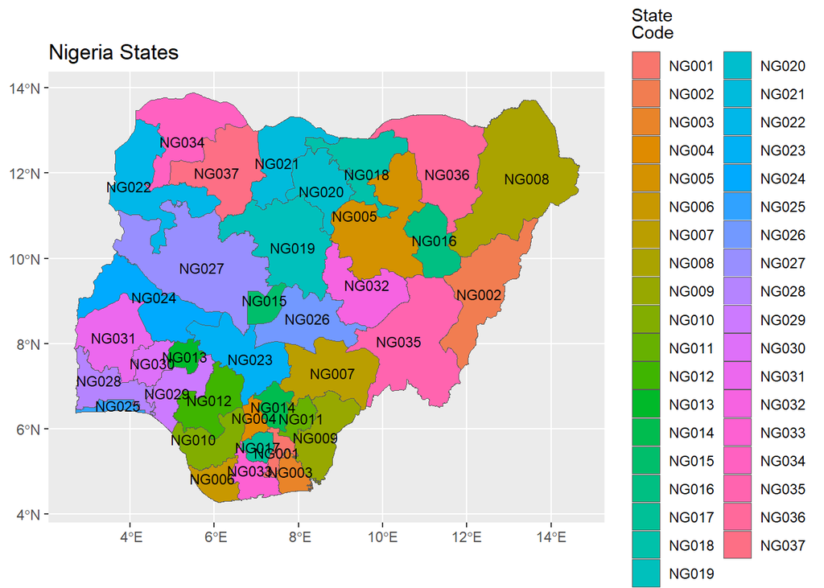

```r
vect_state_geo <- vect("D:/DatosProyecto/SpatialData/Africa/Pais/Nigeria/NGA Admin 2019-2025 OSGOF-Ehealth-UNCS/nga_admin1_topo.topojson")

crs(vect_state_geo) <- "epsg:4326"

vect_state_geo$adm1_pcode <- as.factor(vect_state_geo$adm1_pcode)

# levels(vect_state_geo$adm1_pcode) # Check levels

ggplot(vect_state_geo)+
  geom_spatvector(aes(fill = adm1_pcode)) +
  geom_spatvector_text(aes(label = adm1_pcode), size = 3) +
  labs(
    title = "Nigeria States",
    fill = "State<br>Code") +
  theme(
    plot.title = element_markdown(),
    legend.title = element_markdown(),
    axis.title = element_blank()
  )
```

```r
df_state <- as.data.frame(vect_state_geo)
```

### Load the geopolitical zones

The geopolitical zones are a combination of states with similar ethnic groups, and/or common political history.

There are six zones:

| Zone name | States |
| --- | --- |
| North Central | Benue, Kogi, Kwara, Nasarawa, Niger, and Plateau States, and Federal Capital Territory |
| North East | Adamawa, Bauchi, Borno, Gombe, Taraba, and Yobe |
| North West | Jigawa, Kaduna, Kano, Katsina, Kebbi, Sokoto, and Zamfara |
| South East | Abia, Anambra, Ebonyi, Enugu, and Imo |
| South South | Akwa Ibom, Bayelsa, Cross River, Delta, Edo, and Rivers |
| South West | Ekiti, Lagos, Ogun, Ondo, Osun, and Oyo |

The zones are created by joining the states.

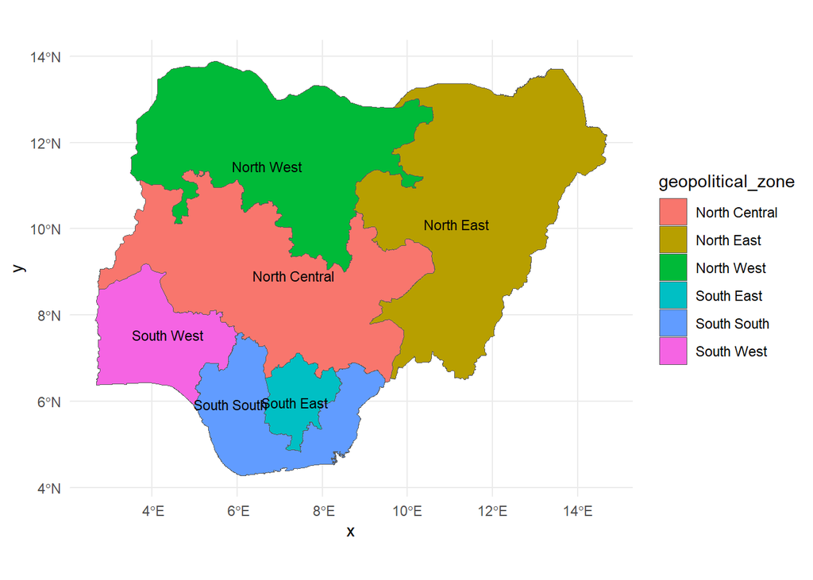

```r
adm1_pcode <- c("NG001", "NG002", "NG003", "NG004", "NG005", "NG006", "NG007", "NG008", "NG009", "NG010", "NG011", "NG012", "NG013", "NG014", "NG015", "NG016", "NG017", "NG018", "NG019", "NG020", "NG021", "NG022", "NG023", "NG024", "NG025", "NG026", "NG027", "NG028", "NG029", "NG030", "NG031", "NG032", "NG033", "NG034", "NG035", "NG036", "NG037")

geopolitical_zone<- c("South East", "North East", "South South", "South East", "North East", "South South", "North Central", "North East", "South South", "South South", "South East", "South South", "South West", "South East", "North Central", "North East", "South East", "North West", "North West", "North West", "North West", "North West", "North Central", "North Central", "South West", "North Central", "North Central", "South West", "South West", "South West", "South West", "North Central", "South South", "North West", "North East", "North East", "North West")

df_gpz <- tibble(adm1_pcode, geopolitical_zone)

vect_gpz_geo <- dplyr::left_join(vect_state_geo, df_gpz, by = c("adm1_pcode")) |> aggregate(by = "geopolitical_zone")

ggplot(vect_gpz_geo)+
  geom_spatvector(aes(fill = geopolitical_zone)) +
  geom_spatvector_text(aes(label = geopolitical_zone), size = 3) +
  theme_minimal()
```

### Load the consumption estimates

```r
df_GHS_crop_state <- read.csv("tab_data/GHS food per capita outputs/crop_state_results.csv")
df_GHS_crop_state <- df_GHS_crop_state |>
  mutate(state = trimws(gsub("[^A-Za-z ]", "", state)))

# change name to match states dataset
df_GHS_crop_state['state'][df_GHS_crop_state['state'] == "FCT"] <- "Federal Capital Territory"

df_GHS_crop_state$state <- as.factor(df_GHS_crop_state$state)

cat(paste(levels(df_GHS_crop_state$state), "; ")) # Check levels
```

Abia ; Adamawa ; Akwa Ibom ; Anambra ; Bauchi ; Bayelsa ; Benue ; Borno ; Cross River ; Delta ; Ebonyi ; Edo ; Ekiti ; Enugu ; Federal Capital Territory ; Gombe ; Imo ; Jigawa ; Kaduna ; Kano ; Katsina ; Kebbi ; Kogi ; Kwara ; Lagos ; Nasarawa ; Niger ; Ogun ; Ondo ; Osun ; Oyo ; Plateau ; Rivers ; Sokoto ; Taraba ; Yobe ; Zamfara ;

```r
df_GHS_crop_zone <- read.csv("tab_data/GHS food per capita outputs/crop_zone_results.csv")

df_GHS_crop_zone <- df_GHS_crop_zone |>
  mutate(zone = trimws(gsub("[^A-Za-z ]", "", zone)))

df_GHS_crop_zone$zone <- as.factor(df_GHS_crop_zone$zone)

cat(paste(levels(df_GHS_crop_zone$zone), "; ")) # Check levels
```

North Central ; North East ; North West ; South East ; South South ; South West ;

### Join to States dataset

```r
vect_state_geo_GHS_crop <- dplyr::left_join(vect_state_geo, df_GHS_crop_state, by = c("adm1_ref_name" = "state"))

vect_state_geo_GHS_crop |> as.data.frame() |>
  DT::datatable(
    rownames = F,
    caption = "GHS crop consumption zone summary",
    filter = "bottom",
    selection = list(mode = "none"),
    editable = FALSE,
    options = list(
      digits = 0,
      scrollX = TRUE,
      scrollCollapse = TRUE,
      autoWidth = TRUE,
      fixedColumns = list(leftColumns = 2),
      lengthMenu = c(15, 40),
      pageLength = 15
    ))
```

| id | area_sqkm | valid_on | valid_to | adm0_pcode | adm0_name3 | adm1_ref_name | adm0_name2 | adm0_name | adm1_pcode | adm0_name1 | lang1 | lang3 | adm1_name3 | adm1_name2 | version | lang | adm1_name1 | adm1_name | lang2 | center_lat | center_lon | crop | crop_equivalent_low | crop_equivalent_kg_person_year | crop_equivalent_high | crop_cv_combined |
| --- | --- | --- | --- | --- | --- | --- | --- | --- | --- | --- | --- | --- | --- | --- | --- | --- | --- | --- | --- | --- | --- | --- | --- | --- | --- | --- |
|  | 4859.5031378 | 2019-04-17T05:00:00Z |  | NG |  | Abia |  | Nigeria | NG001 |  |  |  |  |  | v01 | en |  | Abia |  | 5.4318197 | 7.4883421 | Cassava | 101.0464069780092 | 129.3447661094367 | 171.7839276270817 | 43.09827876864536 |
|  | 4859.5031378 | 2019-04-17T05:00:00Z |  | NG |  | Abia |  | Nigeria | NG001 |  |  |  |  |  | v01 | en |  | Abia |  | 5.4318197 | 7.4883421 | Cocoyam | 0.3928158940304216 | 0.3928158940304216 | 0.3928158940304216 | 52.60885589587019 |
|  | 4859.5031378 | 2019-04-17T05:00:00Z |  | NG |  | Abia |  | Nigeria | NG001 |  |  |  |  |  | v01 | en |  | Abia |  | 5.4318197 | 7.4883421 | Cowpea | 13.24797768354974 | 13.24797768354974 | 13.24797768354974 | 20.70073468176864 |
|  | 4859.5031378 | 2019-04-17T05:00:00Z |  | NG |  | Abia |  | Nigeria | NG001 |  |  |  |  |  | v01 | en |  | Abia |  | 5.4318197 | 7.4883421 | Groundnut | 1.859676359165225 | 1.932977931803633 | 2.006279504442042 | 27.0728865178884 |
|  | 4859.5031378 | 2019-04-17T05:00:00Z |  | NG |  | Abia |  | Nigeria | NG001 |  |  |  |  |  | v01 | en |  | Abia |  | 5.4318197 | 7.4883421 | Maize | 9.779823256526223 | 10.40935770520555 | 11.0398169961988 | 41.42309538085064 |
|  | 4859.5031378 | 2019-04-17T05:00:00Z |  | NG |  | Abia |  | Nigeria | NG001 |  |  |  |  |  | v01 | en |  | Abia |  | 5.4318197 | 7.4883421 | Millet | 0.05021950891393005 | 0.05021950891393005 | 0.05021950891393005 | 99.6821949966931 |
|  | 4859.5031378 | 2019-04-17T05:00:00Z |  | NG |  | Abia |  | Nigeria | NG001 |  |  |  |  |  | v01 | en |  | Abia |  | 5.4318197 | 7.4883421 | Plantain | 8.54741212513508 | 8.54741212513508 | 8.54741212513508 | 16.48091568185804 |
|  | 4859.5031378 | 2019-04-17T05:00:00Z |  | NG |  | Abia |  | Nigeria | NG001 |  |  |  |  |  | v01 | en |  | Abia |  | 5.4318197 | 7.4883421 | Potato | 0.8171467992179345 | 0.8171467992179345 | 0.8171467992179345 | 31.71628237711423 |
|  | 4859.5031378 | 2019-04-17T05:00:00Z |  | NG |  | Abia |  | Nigeria | NG001 |  |  |  |  |  | v01 | en |  | Abia |  | 5.4318197 | 7.4883421 | Rice | 26.49451842224597 | 26.49451842224597 | 26.49451842224597 | 16.52732454438091 |
|  | 4859.5031378 | 2019-04-17T05:00:00Z |  | NG |  | Abia |  | Nigeria | NG001 |  |  |  |  |  | v01 | en |  | Abia |  | 5.4318197 | 7.4883421 | Sorghum | 0.02909683211418591 | 0.02909683211418591 | 0.02909683211418591 | 71.72362860891212 |

[output cut: 508 more lines]

### Join to Zone dataset

```r
vect_gpz_geo_GHS_crop <- dplyr::left_join(vect_gpz_geo, df_GHS_crop_zone, by = c("geopolitical_zone" = "zone"))

vect_gpz_geo_GHS_crop |> as.data.frame() |>
  DT::datatable(
    rownames = F,
    caption = "GHS crop consumption zone summary",
    filter = "bottom",
    selection = list(mode = "none"),
    editable = FALSE,
    options = list(
      digits = 0,
      scrollX = TRUE,
      scrollCollapse = TRUE,
      autoWidth = TRUE,
      fixedColumns = list(leftColumns = 2),
      lengthMenu = c(15, 40),
      pageLength = 15
    ))
```

| geopolitical_zone | mean_area_sqkm | mean_center_lat | mean_center_lon | id | valid_on | valid_to | adm0_pcode | adm0_name3 | adm1_ref_name | adm0_name2 | adm0_name | adm1_pcode | adm0_name1 | lang1 | lang3 | adm1_name3 | adm1_name2 | version | lang | adm1_name1 | adm1_name | lang2 | agg_n | crop | crop_equivalent_low | crop_equivalent_kg_person_year | crop_equivalent_high |
| --- | --- | --- | --- | --- | --- | --- | --- | --- | --- | --- | --- | --- | --- | --- | --- | --- | --- | --- | --- | --- | --- | --- | --- | --- | --- | --- | --- |
| North Central | 32374.02856471428 | 8.683830957142858 | 7.281445614285714 |  | 2019-04-17T05:00:00Z |  | NG |  |  |  | Nigeria |  |  |  |  |  |  | v01 | en |  |  |  | 7 | Cassava | 78.85753208189277 | 89.23083919541823 | 103.9071570870852 |
| North Central | 32374.02856471428 | 8.683830957142858 | 7.281445614285714 |  | 2019-04-17T05:00:00Z |  | NG |  |  |  | Nigeria |  |  |  |  |  |  | v01 | en |  |  |  | 7 | Cocoyam | 0.4077475554690789 | 0.4077475554690789 | 0.4077475554690789 |
| North Central | 32374.02856471428 | 8.683830957142858 | 7.281445614285714 |  | 2019-04-17T05:00:00Z |  | NG |  |  |  | Nigeria |  |  |  |  |  |  | v01 | en |  |  |  | 7 | Cowpea | 10.84222190129688 | 10.84222190129688 | 10.84222190129688 |
| North Central | 32374.02856471428 | 8.683830957142858 | 7.281445614285714 |  | 2019-04-17T05:00:00Z |  | NG |  |  |  | Nigeria |  |  |  |  |  |  | v01 | en |  |  |  | 7 | Groundnut | 1.421413824679271 | 1.492488762637805 | 1.563563700596339 |
| North Central | 32374.02856471428 | 8.683830957142858 | 7.281445614285714 |  | 2019-04-17T05:00:00Z |  | NG |  |  |  | Nigeria |  |  |  |  |  |  | v01 | en |  |  |  | 7 | Maize | 23.22915893712056 | 24.98765186649225 | 27.06991974978846 |
| North Central | 32374.02856471428 | 8.683830957142858 | 7.281445614285714 |  | 2019-04-17T05:00:00Z |  | NG |  |  |  | Nigeria |  |  |  |  |  |  | v01 | en |  |  |  | 7 | Millet | 5.413615891477421 | 5.413615891477421 | 5.413615891477421 |
| North Central | 32374.02856471428 | 8.683830957142858 | 7.281445614285714 |  | 2019-04-17T05:00:00Z |  | NG |  |  |  | Nigeria |  |  |  |  |  |  | v01 | en |  |  |  | 7 | Plantain | 1.200804020202616 | 1.200804020202616 | 1.200804020202616 |
| North Central | 32374.02856471428 | 8.683830957142858 | 7.281445614285714 |  | 2019-04-17T05:00:00Z |  | NG |  |  |  | Nigeria |  |  |  |  |  |  | v01 | en |  |  |  | 7 | Potato | 2.548603853682991 | 2.548603853682991 | 2.548603853682991 |
| North Central | 32374.02856471428 | 8.683830957142858 | 7.281445614285714 |  | 2019-04-17T05:00:00Z |  | NG |  |  |  | Nigeria |  |  |  |  |  |  | v01 | en |  |  |  | 7 | Rice | 26.21800095014167 | 26.21800095014167 | 26.21800095014167 |
| North Central | 32374.02856471428 | 8.683830957142858 | 7.281445614285714 |  | 2019-04-17T05:00:00Z |  | NG |  |  |  | Nigeria |  |  |  |  |  |  | v01 | en |  |  |  | 7 | Sorghum | 16.251231380954 | 16.251231380954 | 16.251231380954 |

[output cut: 74 more lines]

### Plot the Results

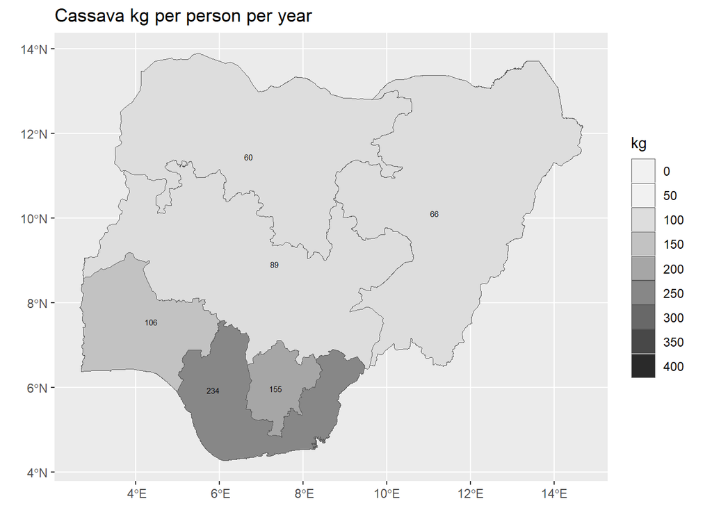

```r
ggplot(tidyterra::filter(vect_gpz_geo_GHS_crop, crop == "Cassava")) +
  geom_spatvector(aes(fill = crop_equivalent_kg_person_year)) +
  geom_spatvector_text(aes(label = round(crop_equivalent_kg_person_year)), size = 2) +
  scale_fill_stepsn(
    n.breaks = 10,
    limits = c(0, 400),
    colours = hcl.colors(palette = "Grays", 10, rev = T),
    guide = "legend",
    na.value = "pink",
    labels = scales::comma
  ) +
  labs(title = "Cassava kg per person per year", fill = "kg") +
  theme(
    plot.title = element_markdown(),
    legend.title = element_markdown(),
    axis.title = element_blank()
  )
```

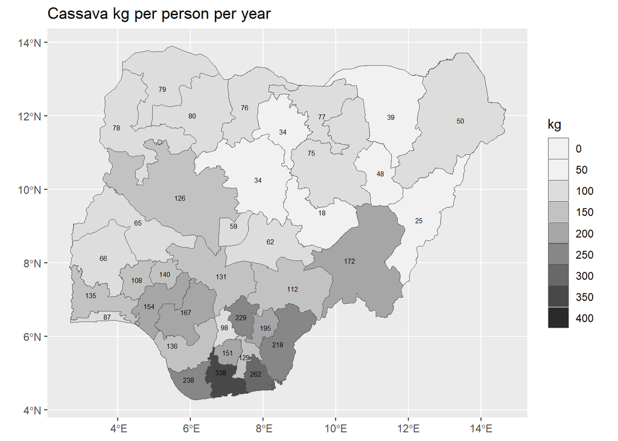

```r
ggplot(tidyterra::filter(vect_state_geo_GHS_crop, crop == "Cassava")) +
  geom_spatvector(aes(fill = crop_equivalent_kg_person_year)) +
  geom_spatvector_text(aes(label = round(crop_equivalent_kg_person_year)), size = 2) +
  scale_fill_stepsn(
    n.breaks = 10,
    limits = c(0, 400),
    colours = hcl.colors(palette = "Grays", 10, rev = T),
    guide = "legend",
    na.value = "pink",
    labels = scales::comma
  ) +
  labs(title = "Cassava kg per person per year", fill = "kg") +
  theme(
    plot.title = element_markdown(),
    legend.title = element_markdown(),
    axis.title = element_blank()
  )
```

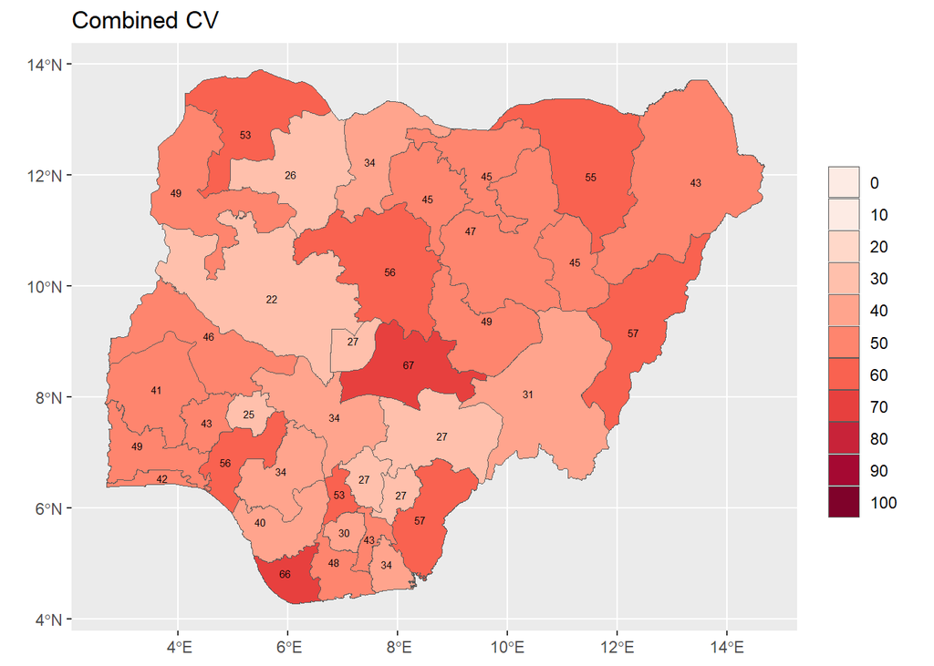

```r
ggplot(tidyterra::filter(vect_state_geo_GHS_crop, crop == "Cassava")) +
  geom_spatvector(aes(fill = crop_cv_combined)) +
  geom_spatvector_text(aes(label = round(crop_cv_combined)), size = 2) +
  scale_fill_stepsn(
    n.breaks = 10,
    limits = c(0, 100),
    colours = hcl.colors(palette = "Reds", 6, rev = T),
    guide = "legend",
    na.value = "pink",
    labels = scales::comma
  ) +
  labs(title = "Combined CV", fill = NA) +
  theme(
    plot.title = element_markdown(),
    legend.title = element_markdown(),
    axis.title = element_blank()
  )
```

#### Cocoyam (Taro) consumption

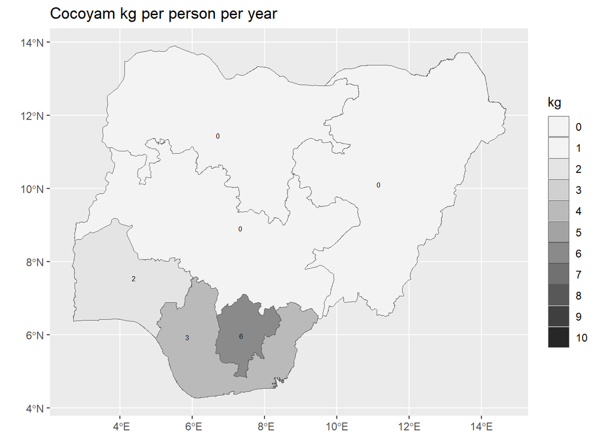

```r
ggplot(tidyterra::filter(vect_gpz_geo_GHS_crop, crop == "Cocoyam")) +
  geom_spatvector(aes(fill = crop_equivalent_kg_person_year)) +
  geom_spatvector_text(aes(label = round(crop_equivalent_kg_person_year)), size = 2) +
  scale_fill_stepsn(
    n.breaks = 10,
    limits = c(0, 10),
    colours = hcl.colors(palette = "Grays", 10, rev = T),
    guide = "legend",
    na.value = "pink",
    labels = scales::comma
  ) +
  labs(title = "Cocoyam kg per person per year", fill = "kg") +
  theme(
    plot.title = element_markdown(),
    legend.title = element_markdown(),
    axis.title = element_blank()
  )
```

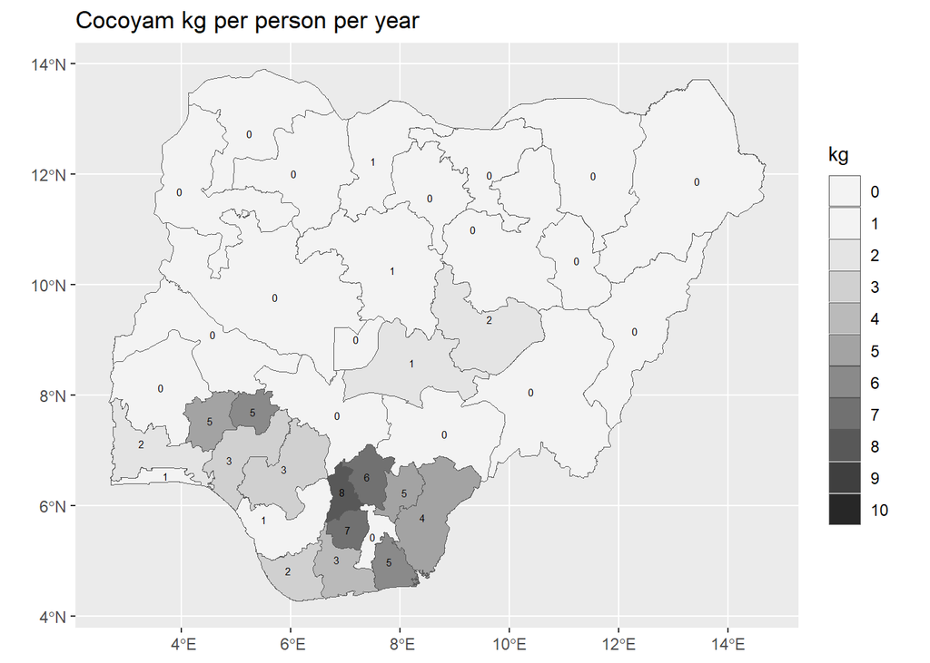

```r
ggplot(tidyterra::filter(vect_state_geo_GHS_crop, crop == "Cocoyam")) +
  geom_spatvector(aes(fill = crop_equivalent_kg_person_year)) +
  geom_spatvector_text(aes(label = round(crop_equivalent_kg_person_year)), size = 2) +
  scale_fill_stepsn(
    n.breaks = 10,
    limits = c(0, 10),
    colours = hcl.colors(palette = "Grays", 10, rev = T),
    guide = "legend",
    na.value = "pink",
    labels = scales::comma
  ) +
  labs(title = "Cocoyam kg per person per year", fill = "kg") +
  theme(
    plot.title = element_markdown(),
    legend.title = element_markdown(),
    axis.title = element_blank()
  )
```

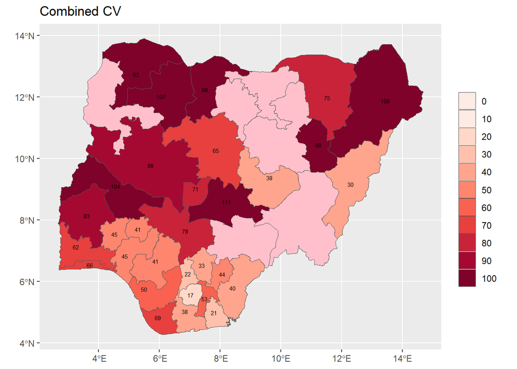

```r
ggplot(tidyterra::filter(vect_state_geo_GHS_crop, crop == "Cocoyam")) +
  geom_spatvector(aes(fill = crop_cv_combined)) +
  geom_spatvector_text(aes(label = round(crop_cv_combined)), size = 2) +
  scale_fill_stepsn(
    n.breaks = 10,
    limits = c(0, 100),
    colours = hcl.colors(palette = "Reds", 6, rev = T),
    guide = "legend",
    na.value = "pink",
    labels = scales::comma
  ) +
  labs(title = "Combined CV", fill = NA) +
  theme(
    plot.title = element_markdown(),
    legend.title = element_markdown(),
    axis.title = element_blank()
  )
```

#### Cowpea consumption

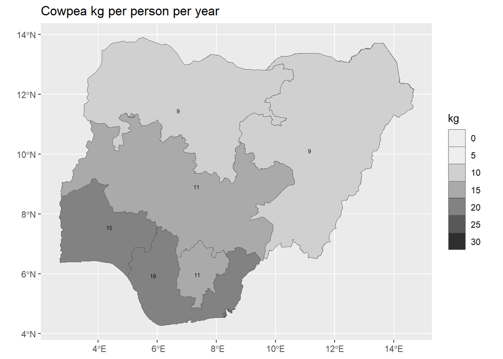

```r
ggplot(tidyterra::filter(vect_gpz_geo_GHS_crop, crop == "Cowpea")) +
  geom_spatvector(aes(fill = crop_equivalent_kg_person_year)) +
  geom_spatvector_text(aes(label = round(crop_equivalent_kg_person_year)), size = 2) +
  scale_fill_stepsn(
    n.breaks = 10,
    limits = c(0, 30),
    colours = hcl.colors(palette = "Grays", 10, rev = T),
    guide = "legend",
    na.value = "pink",
    labels = scales::comma
  ) +
  labs(title = "Cowpea kg per person per year", fill = "kg") +
  theme(
    plot.title = element_markdown(),
    legend.title = element_markdown(),
    axis.title = element_blank()
  )
```

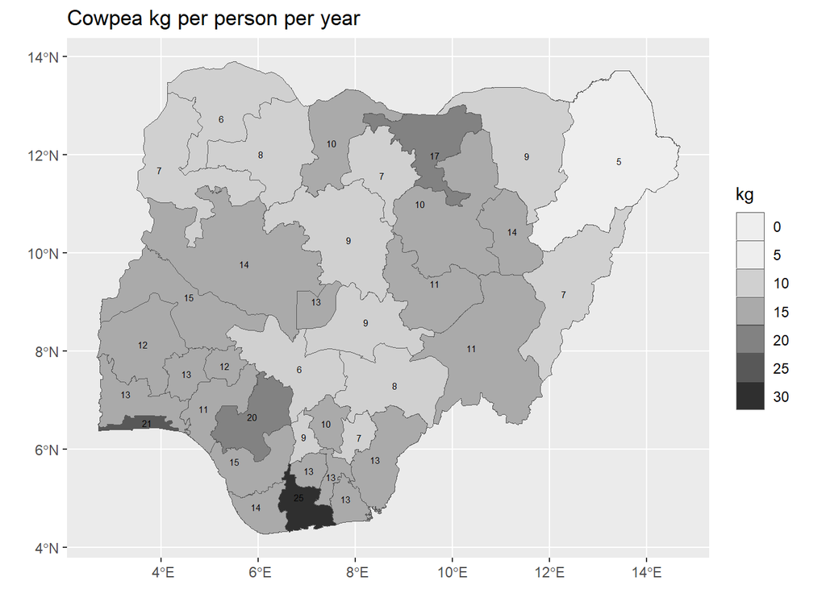

```r
ggplot(tidyterra::filter(vect_state_geo_GHS_crop, crop == "Cowpea")) +
  geom_spatvector(aes(fill = crop_equivalent_kg_person_year)) +
  geom_spatvector_text(aes(label = round(crop_equivalent_kg_person_year)), size = 2) +
  scale_fill_stepsn(
    n.breaks = 10,
    limits = c(0, 30),
    colours = hcl.colors(palette = "Grays", 10, rev = T),
    guide = "legend",
    na.value = "pink",
    labels = scales::comma
  ) +
  labs(title = "Cowpea kg per person per year", fill = "kg") +
  theme(
    plot.title = element_markdown(),
    legend.title = element_markdown(),
    axis.title = element_blank()
  )
```

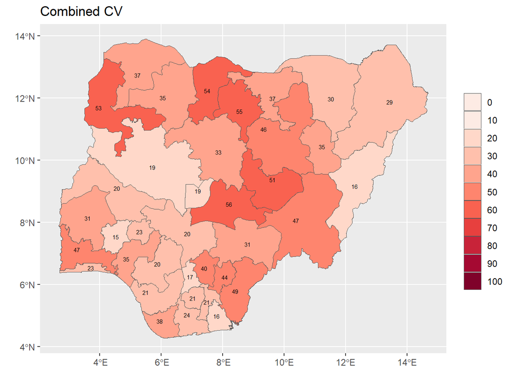

```r
ggplot(tidyterra::filter(vect_state_geo_GHS_crop, crop == "Cowpea")) +
  geom_spatvector(aes(fill = crop_cv_combined)) +
  geom_spatvector_text(aes(label = round(crop_cv_combined)), size = 2) +
  scale_fill_stepsn(
    n.breaks = 10,
    limits = c(0, 100),
    colours = hcl.colors(palette = "Reds", 6, rev = T),
    guide = "legend",
    na.value = "pink",
    labels = scales::comma
  ) +
  labs(title = "Combined CV", fill = NA) +
  theme(
    plot.title = element_markdown(),
    legend.title = element_markdown(),
    axis.title = element_blank()
  )
```

#### Maize consumption

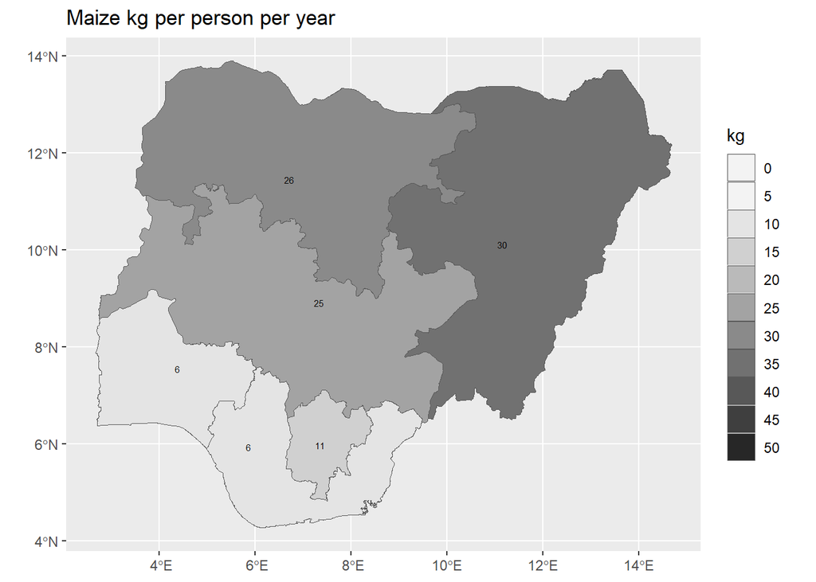

```r
ggplot(tidyterra::filter(vect_gpz_geo_GHS_crop, crop == "Maize")) +
  geom_spatvector(aes(fill = crop_equivalent_kg_person_year)) +
  geom_spatvector_text(aes(label = round(crop_equivalent_kg_person_year)), size = 2) +
  scale_fill_stepsn(
    n.breaks = 10,
    limits = c(0, 50),
    colours = hcl.colors(palette = "Grays", 10, rev = T),
    guide = "legend",
    na.value = "pink",
    labels = scales::comma
  ) +
  labs(title = "Maize kg per person per year", fill = "kg") +
  theme(
    plot.title = element_markdown(),
    legend.title = element_markdown(),
    axis.title = element_blank()
  )
```

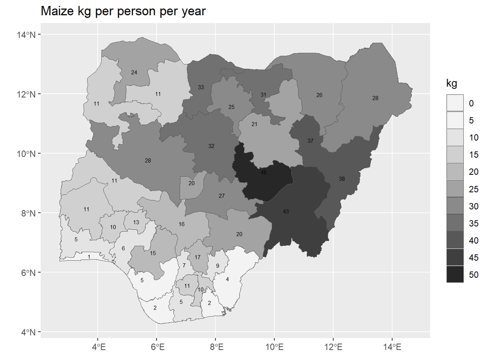

```r
ggplot(tidyterra::filter(vect_state_geo_GHS_crop, crop == "Maize")) +
  geom_spatvector(aes(fill = crop_equivalent_kg_person_year)) +
  geom_spatvector_text(aes(label = round(crop_equivalent_kg_person_year)), size = 2) +
  scale_fill_stepsn(
    n.breaks = 10,
    limits = c(0, 50),
    colours = hcl.colors(palette = "Grays", 10, rev = T),
    guide = "legend",
    na.value = "pink",
    labels = scales::comma
  ) +
  labs(title = "Maize kg per person per year", fill = "kg") +
  theme(
    plot.title = element_markdown(),
    legend.title = element_markdown(),
    axis.title = element_blank()
  )
```

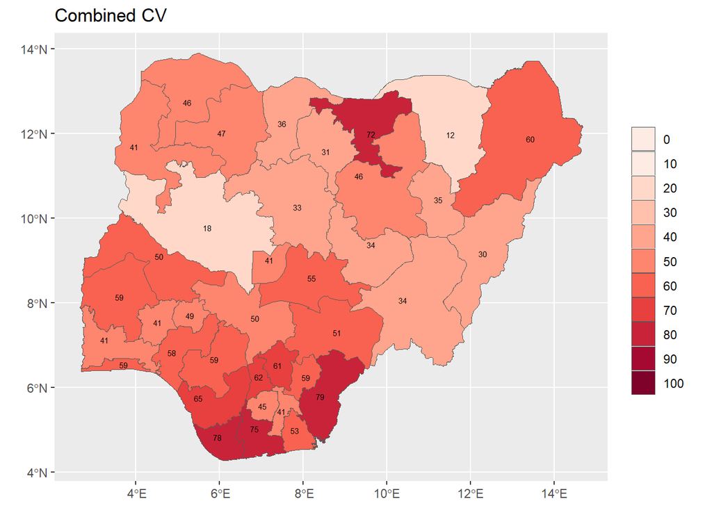

```r
ggplot(tidyterra::filter(vect_state_geo_GHS_crop, crop == "Maize")) +
  geom_spatvector(aes(fill = crop_cv_combined)) +
  geom_spatvector_text(aes(label = round(crop_cv_combined)), size = 2) +
  scale_fill_stepsn(
    n.breaks = 10,
    limits = c(0, 100),
    colours = hcl.colors(palette = "Reds", 6, rev = T),
    guide = "legend",
    na.value = "pink",
    labels = scales::comma
  ) +
  labs(title = "Combined CV", fill = NA) +
  theme(
    plot.title = element_markdown(),
    legend.title = element_markdown(),
    axis.title = element_blank()
  )
```

#### Millet consumption

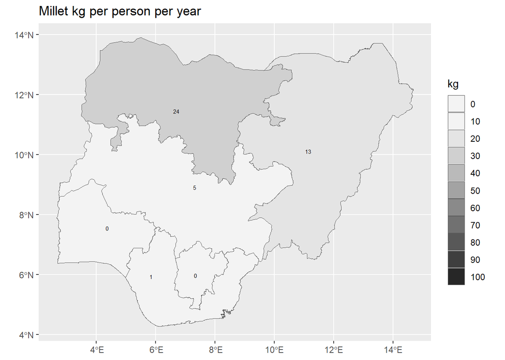

```r
ggplot(tidyterra::filter(vect_gpz_geo_GHS_crop, crop == "Millet")) +
  geom_spatvector(aes(fill = crop_equivalent_kg_person_year)) +
  geom_spatvector_text(aes(label = round(crop_equivalent_kg_person_year)), size = 2) +
  scale_fill_stepsn(
    n.breaks = 10,
    limits = c(0, 100),
    colours = hcl.colors(palette = "Grays", 10, rev = T),
    guide = "legend",
    na.value = "pink",
    labels = scales::comma
  ) +
  labs(title = "Millet kg per person per year", fill = "kg") +
  theme(
    plot.title = element_markdown(),
    legend.title = element_markdown(),
    axis.title = element_blank()
  )
```

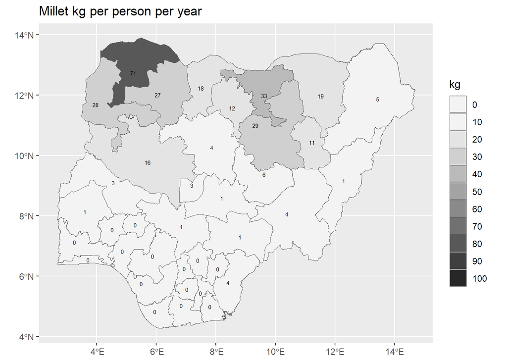

```r
ggplot(tidyterra::filter(vect_state_geo_GHS_crop, crop == "Millet")) +
  geom_spatvector(aes(fill = crop_equivalent_kg_person_year)) +
  geom_spatvector_text(aes(label = round(crop_equivalent_kg_person_year)), size = 2) +
  scale_fill_stepsn(
    n.breaks = 10,
    limits = c(0, 100),
    colours = hcl.colors(palette = "Grays", 10, rev = T),
    guide = "legend",
    na.value = "pink",
    labels = scales::comma
  ) +
  labs(title = "Millet kg per person per year", fill = "kg") +
  theme(
    plot.title = element_markdown(),
    legend.title = element_markdown(),
    axis.title = element_blank()
  )
```

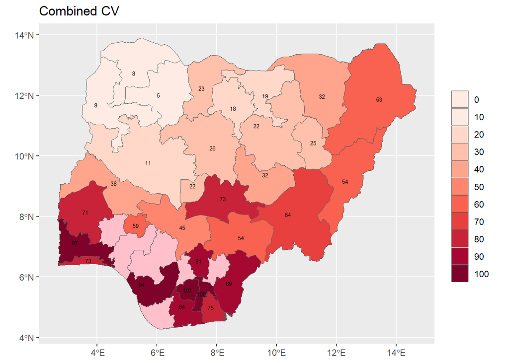

```r
ggplot(tidyterra::filter(vect_state_geo_GHS_crop, crop == "Millet")) +
  geom_spatvector(aes(fill = crop_cv_combined)) +
  geom_spatvector_text(aes(label = round(crop_cv_combined)), size = 2) +
  scale_fill_stepsn(
    n.breaks = 10,
    limits = c(0, 100),
    colours = hcl.colors(palette = "Reds", 6, rev = T),
    guide = "legend",
    na.value = "pink",
    labels = scales::comma
  ) +
  labs(title = "Combined CV", fill = NA) +
  theme(
    plot.title = element_markdown(),
    legend.title = element_markdown(),
    axis.title = element_blank()
  )
```

#### Potato consumption

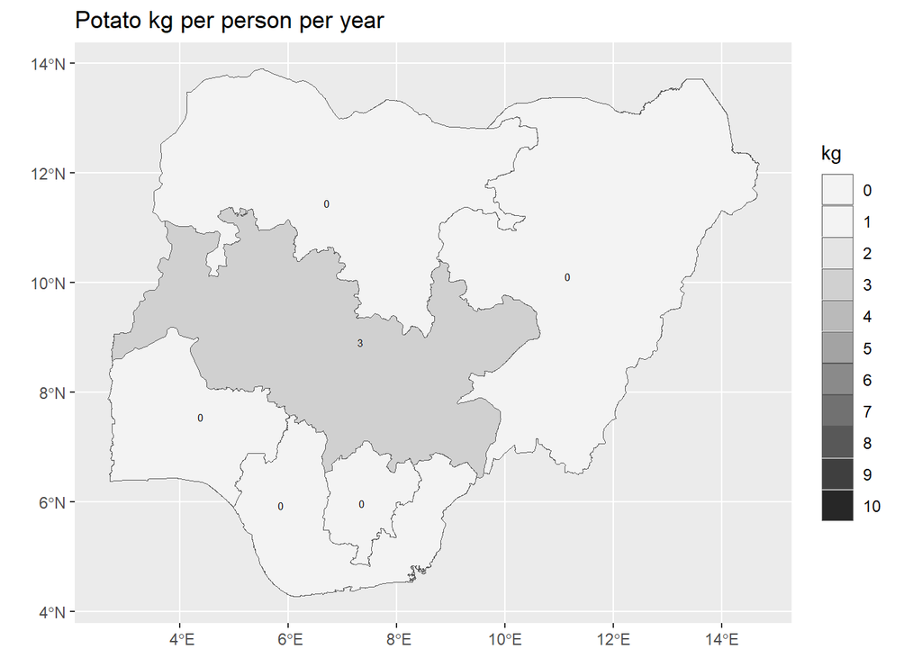

```r
ggplot(tidyterra::filter(vect_gpz_geo_GHS_crop, crop == "Potato")) +
  geom_spatvector(aes(fill = crop_equivalent_kg_person_year)) +
  geom_spatvector_text(aes(label = round(crop_equivalent_kg_person_year)), size = 2) +
  scale_fill_stepsn(
    n.breaks = 10,
    limits = c(0, 10),
    colours = hcl.colors(palette = "Grays", 10, rev = T),
    guide = "legend",
    na.value = "pink",
    labels = scales::comma
  ) +
  labs(title = "Potato kg per person per year", fill = "kg") +
  theme(
    plot.title = element_markdown(),
    legend.title = element_markdown(),
    axis.title = element_blank()
  )
```

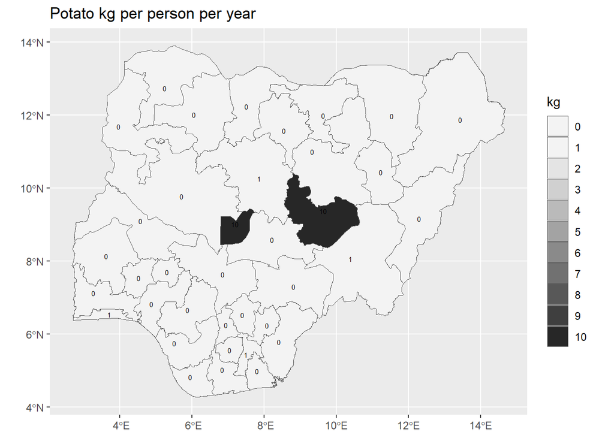

```r
ggplot(tidyterra::filter(vect_state_geo_GHS_crop, crop == "Potato")) +
  geom_spatvector(aes(fill = crop_equivalent_kg_person_year)) +
  geom_spatvector_text(aes(label = round(crop_equivalent_kg_person_year)), size = 2) +
  scale_fill_stepsn(
    n.breaks = 10,
    limits = c(0, 10),
    colours = hcl.colors(palette = "Grays", 10, rev = T),
    guide = "legend",
    na.value = "pink",
    labels = scales::comma
  ) +
  labs(title = "Potato kg per person per year", fill = "kg") +
  theme(
    plot.title = element_markdown(),
    legend.title = element_markdown(),
    axis.title = element_blank()
  )
```

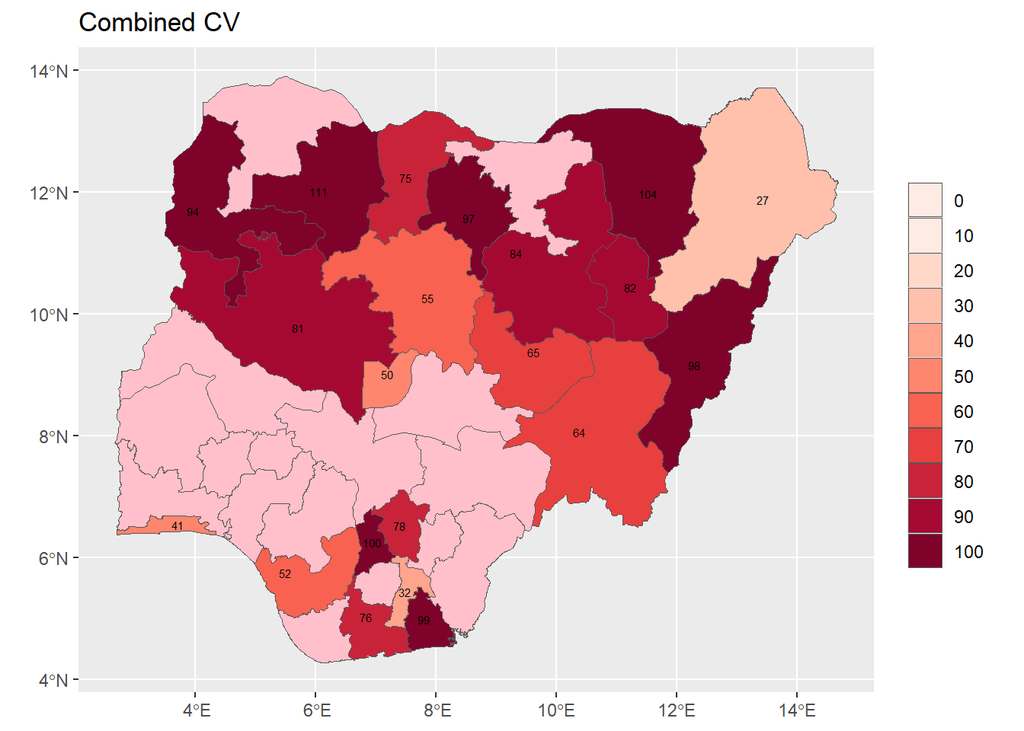

```r
ggplot(tidyterra::filter(vect_state_geo_GHS_crop, crop == "Potato")) +
  geom_spatvector(aes(fill = crop_cv_combined)) +
  geom_spatvector_text(aes(label = round(crop_cv_combined)), size = 2) +
  scale_fill_stepsn(
    n.breaks = 10,
    limits = c(0, 100),
    colours = hcl.colors(palette = "Reds", 6, rev = T),
    guide = "legend",
    na.value = "pink",
    labels = scales::comma
  ) +
  labs(title = "Combined CV", fill = NA) +
  theme(
    plot.title = element_markdown(),
    legend.title = element_markdown(),
    axis.title = element_blank()
  )
```

#### Plantain consumption

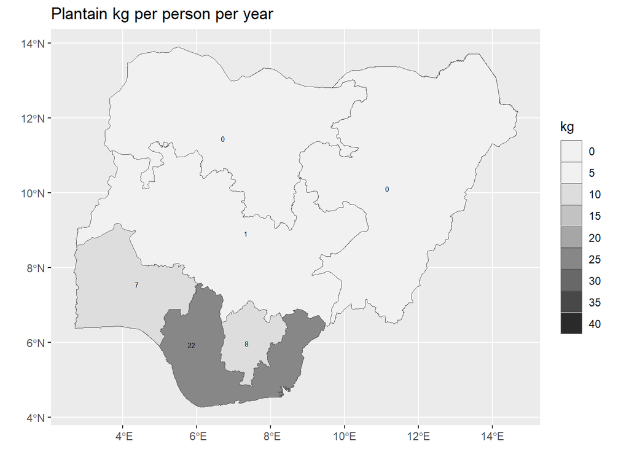

```r
ggplot(tidyterra::filter(vect_gpz_geo_GHS_crop, crop == "Plantain")) +
  geom_spatvector(aes(fill = crop_equivalent_kg_person_year)) +
  geom_spatvector_text(aes(label = round(crop_equivalent_kg_person_year)), size = 2) +
  scale_fill_stepsn(
    n.breaks = 10,
    limits = c(0, 40),
    colours = hcl.colors(palette = "Grays", 10, rev = T),
    guide = "legend",
    na.value = "pink",
    labels = scales::comma
  ) +
  labs(title = "Plantain kg per person per year", fill = "kg") +
  theme(
    plot.title = element_markdown(),
    legend.title = element_markdown(),
    axis.title = element_blank()
  )
```

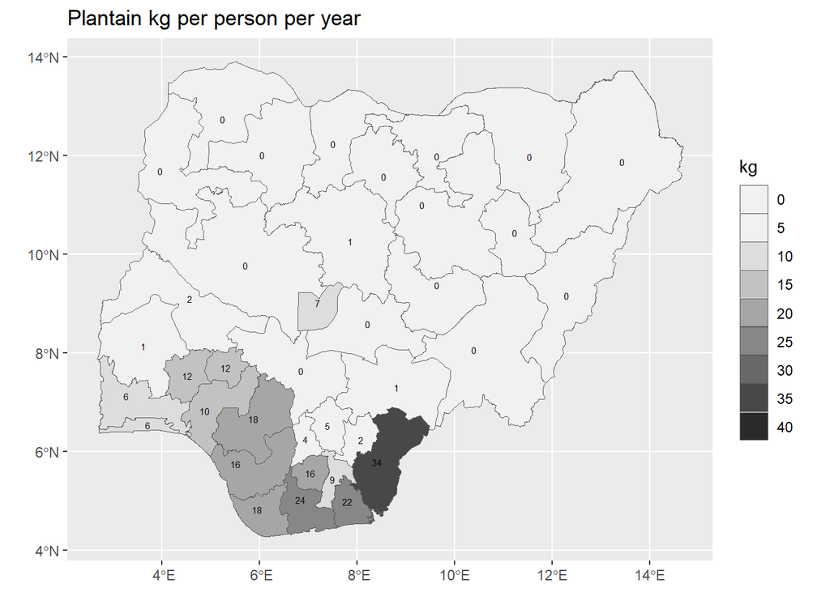

```r
ggplot(tidyterra::filter(vect_state_geo_GHS_crop, crop == "Plantain")) +
  geom_spatvector(aes(fill = crop_equivalent_kg_person_year)) +
  geom_spatvector_text(aes(label = round(crop_equivalent_kg_person_year)), size = 2) +
  scale_fill_stepsn(
    n.breaks = 10,
    limits = c(0, 40),
    colours = hcl.colors(palette = "Grays", 10, rev = T),
    guide = "legend",
    na.value = "pink",
    labels = scales::comma
  ) +
  labs(title = "Plantain kg per person per year", fill = "kg") +
  theme(
    plot.title = element_markdown(),
    legend.title = element_markdown(),
    axis.title = element_blank()
  )
```

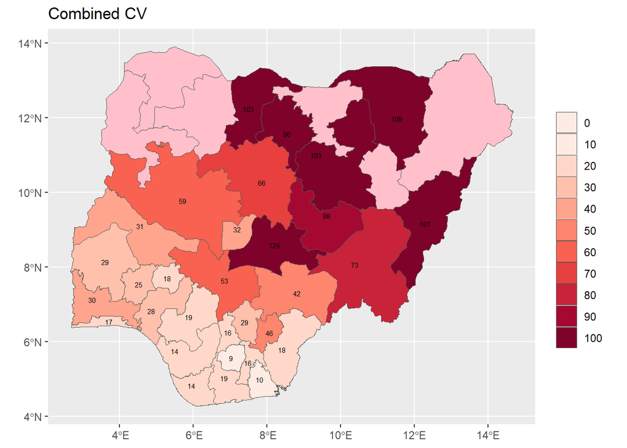

```r
ggplot(tidyterra::filter(vect_state_geo_GHS_crop, crop == "Plantain")) +
  geom_spatvector(aes(fill = crop_cv_combined)) +
  geom_spatvector_text(aes(label = round(crop_cv_combined)), size = 2) +
  scale_fill_stepsn(
    n.breaks = 10,
    limits = c(0, 100),
    colours = hcl.colors(palette = "Reds", 6, rev = T),
    guide = "legend",
    na.value = "pink",
    labels = scales::comma
  ) +
  labs(title = "Combined CV", fill = NA) +
  theme(
    plot.title = element_markdown(),
    legend.title = element_markdown(),
    axis.title = element_blank()
  )
```

#### Rice consumption

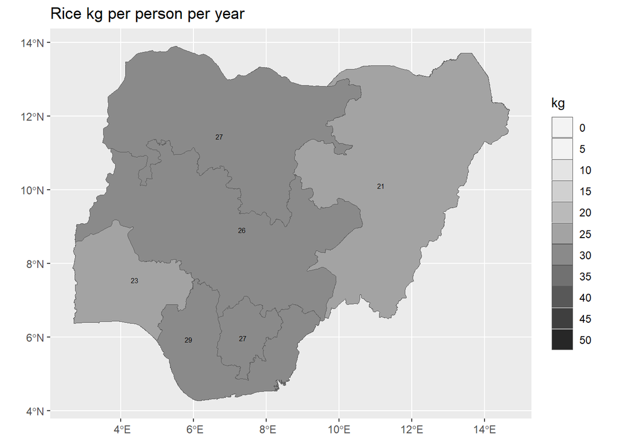

```r
ggplot(tidyterra::filter(vect_gpz_geo_GHS_crop, crop == "Rice")) +
  geom_spatvector(aes(fill = crop_equivalent_kg_person_year)) +
  geom_spatvector_text(aes(label = round(crop_equivalent_kg_person_year)), size = 2) +
  scale_fill_stepsn(
    n.breaks = 10,
    limits = c(0, 50),
    colours = hcl.colors(palette = "Grays", 10, rev = T),
    guide = "legend",
    na.value = "pink",
    labels = scales::comma
  ) +
  labs(title = "Rice kg per person per year", fill = "kg") +
  theme(
    plot.title = element_markdown(),
    legend.title = element_markdown(),
    axis.title = element_blank()
  )
```

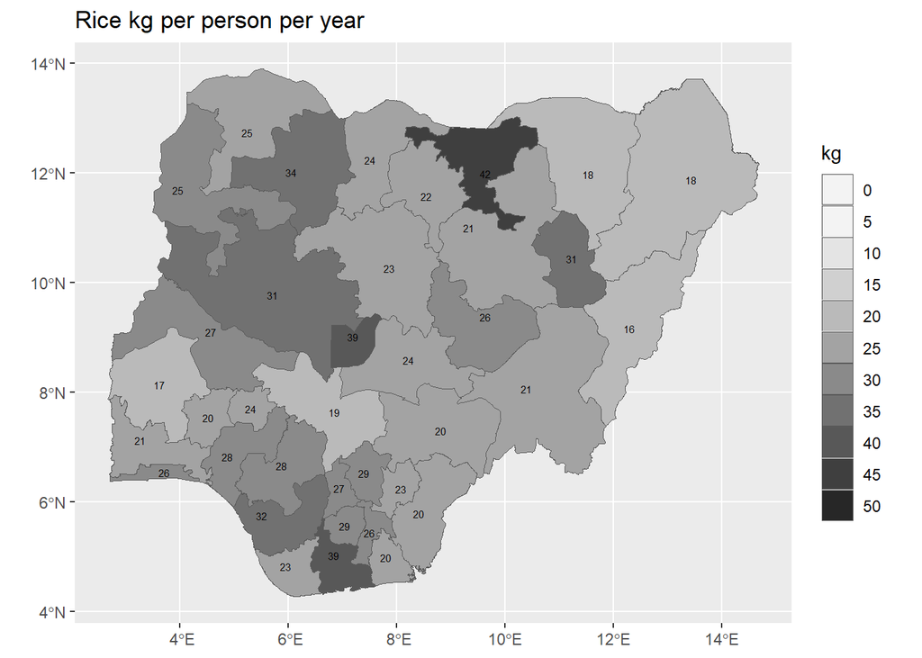

```r
ggplot(tidyterra::filter(vect_state_geo_GHS_crop, crop == "Rice")) +
  geom_spatvector(aes(fill = crop_equivalent_kg_person_year)) +
  geom_spatvector_text(aes(label = round(crop_equivalent_kg_person_year)), size = 2) +
  scale_fill_stepsn(
    n.breaks = 10,
    limits = c(0, 50),
    colours = hcl.colors(palette = "Grays", 10, rev = T),
    guide = "legend",
    na.value = "pink",
    labels = scales::comma
  ) +
  labs(title = "Rice kg per person per year", fill = "kg") +
  theme(
    plot.title = element_markdown(),
    legend.title = element_markdown(),
    axis.title = element_blank()
  )
```

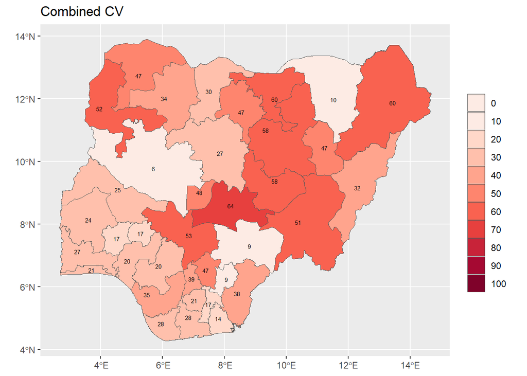

```r
ggplot(tidyterra::filter(vect_state_geo_GHS_crop, crop == "Rice")) +
  geom_spatvector(aes(fill = crop_cv_combined)) +
  geom_spatvector_text(aes(label = round(crop_cv_combined)), size = 2) +
  scale_fill_stepsn(
    n.breaks = 10,
    limits = c(0, 100),
    colours = hcl.colors(palette = "Reds", 6, rev = T),
    guide = "legend",
    na.value = "pink",
    labels = scales::comma
  ) +
  labs(title = "Combined CV", fill = NA) +
  theme(
    plot.title = element_markdown(),
    legend.title = element_markdown(),
    axis.title = element_blank()
  )
```

#### Sorghum consumption

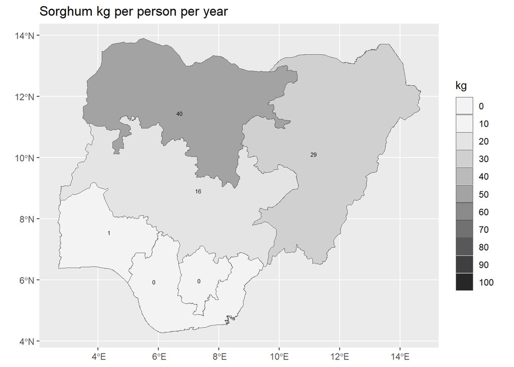

```r
ggplot(tidyterra::filter(vect_gpz_geo_GHS_crop, crop == "Sorghum")) +
  geom_spatvector(aes(fill = crop_equivalent_kg_person_year)) +
  geom_spatvector_text(aes(label = round(crop_equivalent_kg_person_year)), size = 2) +
  scale_fill_stepsn(
    n.breaks = 10,
    limits = c(0, 100),
    colours = hcl.colors(palette = "Grays", 10, rev = T),
    guide = "legend",
    na.value = "pink",
    labels = scales::comma
  ) +
  labs(title = "Sorghum kg per person per year", fill = "kg") +
  theme(
    plot.title = element_markdown(),
    legend.title = element_markdown(),
    axis.title = element_blank()
  )
```

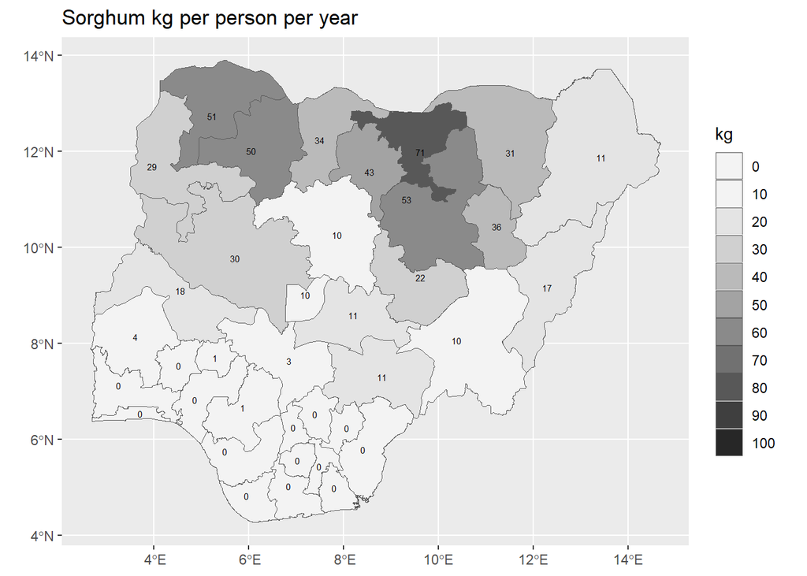

```r
ggplot(tidyterra::filter(vect_state_geo_GHS_crop, crop == "Sorghum")) +
  geom_spatvector(aes(fill = crop_equivalent_kg_person_year)) +
  geom_spatvector_text(aes(label = round(crop_equivalent_kg_person_year)), size = 2) +
  scale_fill_stepsn(
    n.breaks = 10,
    limits = c(0, 100),
    colours = hcl.colors(palette = "Grays", 10, rev = T),
    guide = "legend",
    na.value = "pink",
    labels = scales::comma
  ) +
  labs(title = "Sorghum kg per person per year", fill = "kg") +
  theme(
    plot.title = element_markdown(),
    legend.title = element_markdown(),
    axis.title = element_blank()
  )
```

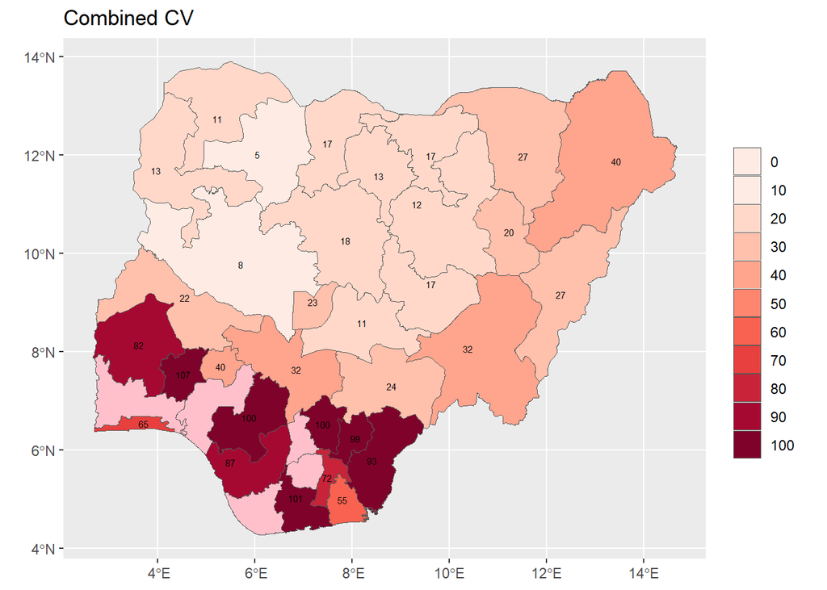

```r
ggplot(tidyterra::filter(vect_state_geo_GHS_crop, crop == "Sorghum")) +
  geom_spatvector(aes(fill = crop_cv_combined)) +
  geom_spatvector_text(aes(label = round(crop_cv_combined)), size = 2) +
  scale_fill_stepsn(
    n.breaks = 10,
    limits = c(0, 100),
    colours = hcl.colors(palette = "Reds", 6, rev = T),
    guide = "legend",
    na.value = "pink",
    labels = scales::comma
  ) +
  labs(title = "Combined CV", fill = NA) +
  theme(
    plot.title = element_markdown(),
    legend.title = element_markdown(),
    axis.title = element_blank()
  )
```

#### Sweet Potato consumption

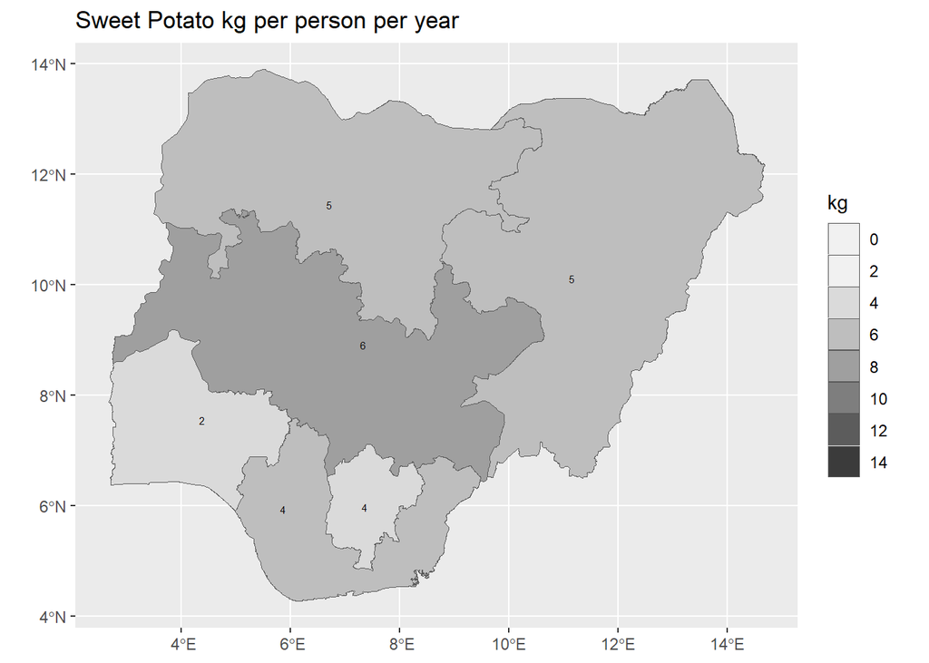

```r
ggplot(tidyterra::filter(vect_gpz_geo_GHS_crop, crop == "Sweet potato")) +
  geom_spatvector(aes(fill = crop_equivalent_kg_person_year)) +
  geom_spatvector_text(aes(label = round(crop_equivalent_kg_person_year)), size = 2) +
  scale_fill_stepsn(
    n.breaks = 10,
    limits = c(0, 15),
    colours = hcl.colors(palette = "Grays", 10, rev = T),
    guide = "legend",
    na.value = "pink",
    labels = scales::comma
  ) +
  labs(title = "Sweet Potato kg per person per year", fill = "kg") +
  theme(
    plot.title = element_markdown(),
    legend.title = element_markdown(),
    axis.title = element_blank()
  )
```

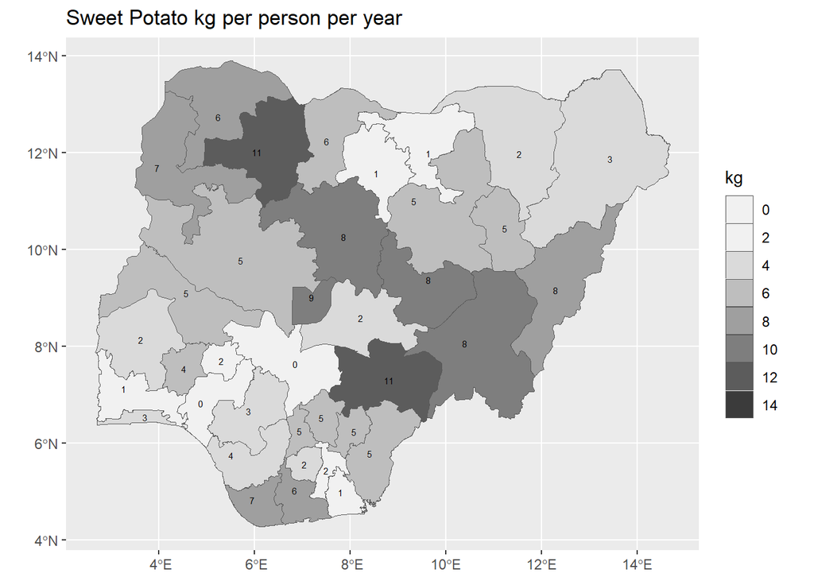

```r
ggplot(tidyterra::filter(vect_state_geo_GHS_crop, crop == "Sweet potato")) +
  geom_spatvector(aes(fill = crop_equivalent_kg_person_year)) +
  geom_spatvector_text(aes(label = round(crop_equivalent_kg_person_year)), size = 2) +
  scale_fill_stepsn(
    n.breaks = 10,
    limits = c(0, 15),
    colours = hcl.colors(palette = "Grays", 10, rev = T),
    guide = "legend",
    na.value = "pink",
    labels = scales::comma
  ) +
  labs(title = "Sweet Potato kg per person per year", fill = "kg") +
  theme(
    plot.title = element_markdown(),
    legend.title = element_markdown(),
    axis.title = element_blank()
  )
```

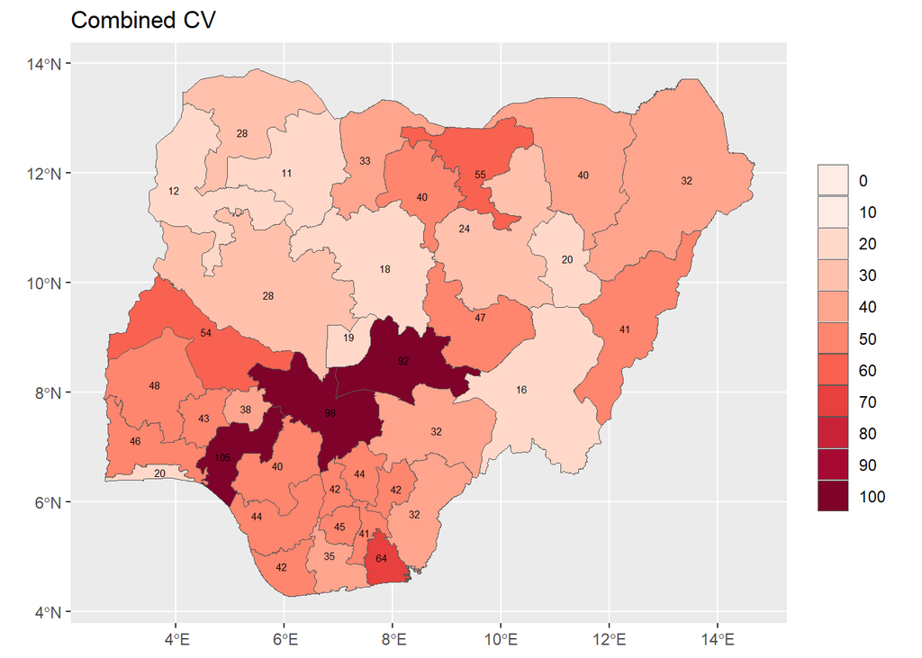

```r
ggplot(tidyterra::filter(vect_state_geo_GHS_crop, crop == "Sweet potato")) +
  geom_spatvector(aes(fill = crop_cv_combined)) +
  geom_spatvector_text(aes(label = round(crop_cv_combined)), size = 2) +
  scale_fill_stepsn(
    n.breaks = 10,
    limits = c(0, 100),
    colours = hcl.colors(palette = "Reds", 6, rev = T),
    guide = "legend",
    na.value = "pink",
    labels = scales::comma
  ) +
  labs(title = "Combined CV", fill = NA) +
  theme(
    plot.title = element_markdown(),
    legend.title = element_markdown(),
    axis.title = element_blank()
  )
```